# **Nama: Hasbi Thaufik Oktodila**

email : htoktodila@gmail.com  
linkedin : [Link](https://www.linkedin.com/in/hasbithaufik/)  
phone: +6281374160173

```python
print('Hasbi Thaufik Oktodila')
```

```
Hasbi Thaufik Oktodila
```

# **Importing Basic Libraries**

```python
import pandas as pd             # dataframe handling
import numpy as np              # math operation and arrays handling
import matplotlib.pyplot as plt # visualisation
import seaborn as sns           # visualisation

# Vieweing setting
pd.set_option('display.max_columns', None)

# warning settings
import warnings
warnings.filterwarnings(action='ignore')    # ignore warnings
```

# **Dataset :**

The data contains demographic details, work-related metrics and attrition flag.

- **EmployeeNumber** - Employee Identifier
- **Attrition** - Did the employee attrite?
- **Age** - Age of the employee
- **BusinessTravel** - Travel commitments for the job
- **DailyRate** - Data description not available**
- **Department** - Employee Department
- **DistanceFromHome** - Distance from work to home (in km)
- **Education** - 1-Below College, 2-College, 3-Bachelor, 4-Master,5-Doctor
- **EducationField** - Field of Education
- **EnvironmentSatisfaction** - 1-Low, 2-Medium, 3-High, 4-Very High
- **Gender** - Employee's gender
- **HourlyRate** - Data description not available**
- **JobInvolvement** - 1-Low, 2-Medium, 3-High, 4-Very High
- **JobLevel** - Level of job (1 to 5)
- **JobRole** - Job Roles
- **JobSatisfaction** - 1-Low, 2-Medium, 3-High, 4-Very High
- **MaritalStatus** - Marital Status
- **MonthlyIncome** - Monthly Salary
- **MonthlyRate** - Data description not available**
- **NumCompaniesWorked** - Number of companies worked at
- **Over18** - Over 18 years of age?
- **OverTime** - Overtime?
- **PercentSalaryHike** - The percentage increase in salary last year
- **PerformanceRating** - 1-Low, 2-Good, 3-Excellent, 4-Outstanding
- **RelationshipSatisfaction** - 1-Low, 2-Medium, 3-High, 4-Very High
- **StandardHours** - Standard Hours
- **StockOptionLevel** - Stock Option Level
- **TotalWorkingYears** - Total years worked
- **TrainingTimesLastYear** - Number of training attended last year
- **WorkLifeBalance** - 1-Low, 2-Good, 3-Excellent, 4-Outstanding
- **YearsAtCompany** - Years at Company
- **YearsInCurrentRole** - Years in the current role
- **YearsSinceLastPromotion** - Years since the last promotion
- **YearsWithCurrManager** - Years with the current manager

## Loading The dataset

```python
df = pd.read_csv('employee.csv')
df
```

|  | Unnamed: 0 | EmployeeNumber | Attrition | Age | BusinessTravel | DailyRate | Department | DistanceFromHome | Education | EducationField | EnvironmentSatisfaction | Gender | HourlyRate | JobInvolvement | JobLevel | JobRole | JobSatisfaction | MaritalStatus | MonthlyIncome | MonthlyRate | NumCompaniesWorked | Over18 | OverTime | PercentSalaryHike | PerformanceRating | RelationshipSatisfaction | StandardHours | StockOptionLevel | TotalWorkingYears | … |
| --- | --- | --- | --- | --- | --- | --- | --- | --- | --- | --- | --- | --- | --- | --- | --- | --- | --- | --- | --- | --- | --- | --- | --- | --- | --- | --- | --- | --- | --- | --- |
| 0 | 0 | 1 | Yes | 41 | Travel_Rarely | 1102 | Sales | 1 | 2 | Life Sciences | 2 | Female | 94 | 3 | 2 | Sales Executive | 4 | Single | 5993 | 19479 | 8 | Y | Yes | 11 | 3 | 1 | 80 | 0 | 8 | … |
| 1 | 1 | 2 | No | 49 | Travel_Frequently | 279 | Research & Development | 8 | 1 | Life Sciences | 3 | Male | 61 | 2 | 2 | Research Scientist | 2 | Married | 5130 | 24907 | 1 | Y | No | 23 | 4 | 4 | 80 | 1 | 10 | … |
| 2 | 2 | 3 | Yes | 37 | Travel_Rarely | 1373 | Research & Development | 2 | 2 | Other | 4 | Male | 92 | 2 | 1 | Laboratory Technician | 3 | Single | 2090 | 2396 | 6 | Y | Yes | 15 | 3 | 2 | 80 | 0 | 7 | … |
| 3 | 3 | 4 | No | 33 | Travel_Frequently | 1392 | Research & Development | 3 | 4 | Life Sciences | 4 | Female | 56 | 3 | 1 | Research Scientist | 3 | Married | 2909 | 23159 | 1 | Y | Yes | 11 | 3 | 3 | 80 | 0 | 8 | … |
| 4 | 4 | 5 | No | 27 | Travel_Rarely | 591 | Research & Development | 2 | 1 | Medical | 1 | Male | 40 | 3 | 1 | Laboratory Technician | 2 | Married | 3468 | 16632 | 9 | Y | No | 12 | 3 | 4 | 80 | 1 | 6 | … |
| ... | ... | ... | ... | ... | ... | ... | ... | ... | ... | ... | ... | ... | ... | ... | ... | ... | ... | ... | ... | ... | ... | ... | ... | ... | ... | ... | ... | ... | ... | … |
| 2935 | 2935 | 2936 | No | 36 | Travel_Frequently | 884 | Research & Development | 23 | 2 | Medical | 3 | Male | 41 | 4 | 2 | Laboratory Technician | 4 | Married | 2571 | 12290 | 4 | Y | No | 17 | 3 | 3 | 80 | 1 | 17 | … |
| 2936 | 2936 | 2937 | No | 39 | Travel_Rarely | 613 | Research & Development | 6 | 1 | Medical | 4 | Male | 42 | 2 | 3 | Healthcare Representative | 1 | Married | 9991 | 21457 | 4 | Y | No | 15 | 3 | 1 | 80 | 1 | 9 | … |
| 2937 | 2937 | 2938 | No | 27 | Travel_Rarely | 155 | Research & Development | 4 | 3 | Life Sciences | 2 | Male | 87 | 4 | 2 | Manufacturing Director | 2 | Married | 6142 | 5174 | 1 | Y | Yes | 20 | 4 | 2 | 80 | 1 | 6 | … |
| 2938 | 2938 | 2939 | No | 49 | Travel_Frequently | 1023 | Sales | 2 | 3 | Medical | 4 | Male | 63 | 2 | 2 | Sales Executive | 2 | Married | 5390 | 13243 | 2 | Y | No | 14 | 3 | 4 | 80 | 0 | 17 | … |
| 2939 | 2939 | 2940 | No | 34 | Travel_Rarely | 628 | Research & Development | 8 | 3 | Medical | 2 | Male | 82 | 4 | 2 | Laboratory Technician | 3 | Married | 4404 | 10228 | 2 | Y | No | 12 | 3 | 1 | 80 | 0 | 6 | … |

2940 rows × 35 columns

## Dataset Basic Info

```python
df.info()
```

```
<class 'pandas.core.frame.DataFrame'>
RangeIndex: 2940 entries, 0 to 2939
Data columns (total 35 columns):
 #   Column                    Non-Null Count  Dtype
---  ------                    --------------  -----
 0   Unnamed: 0                2940 non-null   int64
 1   EmployeeNumber            2940 non-null   int64
 2   Attrition                 2940 non-null   object
 3   Age                       2940 non-null   int64
 4   BusinessTravel            2940 non-null   object
 5   DailyRate                 2940 non-null   int64
 6   Department                2940 non-null   object
 7   DistanceFromHome          2940 non-null   int64
 8   Education                 2940 non-null   int64
 9   EducationField            2940 non-null   object
```

[output cut: 27 more lines]

```python
df.isnull().sum()
```

```
Unnamed: 0                  0
EmployeeNumber              0
Attrition                   0
Age                         0
BusinessTravel              0
DailyRate                   0
Department                  0
DistanceFromHome            0
Education                   0
EducationField              0
EnvironmentSatisfaction     0
Gender                      0
HourlyRate                  0
JobInvolvement              0
JobLevel                    0
JobRole                     0
JobSatisfaction             0
MaritalStatus               0
MonthlyIncome               0
MonthlyRate                 0
NumCompaniesWorked          0
Over18                      0
OverTime                    0
PercentSalaryHike           0
PerformanceRating           0
RelationshipSatisfaction    0
StandardHours               0
StockOptionLevel            0
TotalWorkingYears           0
TrainingTimesLastYear       0
WorkLifeBalance             0
YearsAtCompany              0
YearsInCurrentRole          0
YearsSinceLastPromotion     0
YearsWithCurrManager        0
dtype: int64
```

```python
df.duplicated().any()
```

```
False
```

# **EDA**

**(1) Drop semua kolom yang tidak diperlukan pada data employee.csv. Lakukan EDA univariat untuk setiap kolom numerik pada employee.csv yang mencakup:**

a. histogram dan boxplot untuk tiap kolom

b. metrik statistik dasar untuk tiap kolom: mean, std, min, q1, q2, q3, iqr, max

c. identifikasi nilai upper whisker dan lower whisker dari boxplot tiap kolom

d. apabila terdapat outlier (<q1-1.5*iqr | >q3+1.5*iqr): hitung count, proportion, dan list dari outlier tiap kolom

e. identifikasi hal yang menurut anda menarik dari hasil EDA yang Anda dapatkan

## **Jawaban:**

## **Statistik Dasar**

```python
basicstats = df.describe().T
basicstats['iqr'] = (basicstats['75%'] - basicstats['25%'])
basicstats
```

|  | count | mean | std | min | 25% | 50% | 75% | max | iqr |
| --- | --- | --- | --- | --- | --- | --- | --- | --- | --- |
| Unnamed: 0 | 2940.0 | 1469.500000 | 848.849221 | 0.0 | 734.75 | 1469.5 | 2204.25 | 2939.0 | 1469.5 |
| EmployeeNumber | 2940.0 | 1470.500000 | 848.849221 | 1.0 | 735.75 | 1470.5 | 2205.25 | 2940.0 | 1469.5 |
| Age | 2940.0 | 36.923810 | 9.133819 | 18.0 | 30.00 | 36.0 | 43.00 | 60.0 | 13.0 |
| DailyRate | 2940.0 | 802.485714 | 403.440447 | 102.0 | 465.00 | 802.0 | 1157.00 | 1499.0 | 692.0 |
| DistanceFromHome | 2940.0 | 9.192517 | 8.105485 | 1.0 | 2.00 | 7.0 | 14.00 | 29.0 | 12.0 |
| Education | 2940.0 | 2.912925 | 1.023991 | 1.0 | 2.00 | 3.0 | 4.00 | 5.0 | 2.0 |
| EnvironmentSatisfaction | 2940.0 | 2.721769 | 1.092896 | 1.0 | 2.00 | 3.0 | 4.00 | 4.0 | 2.0 |
| HourlyRate | 2940.0 | 65.891156 | 20.325969 | 30.0 | 48.00 | 66.0 | 84.00 | 100.0 | 36.0 |
| JobInvolvement | 2940.0 | 2.729932 | 0.711440 | 1.0 | 2.00 | 3.0 | 3.00 | 4.0 | 1.0 |
| JobLevel | 2940.0 | 2.063946 | 1.106752 | 1.0 | 1.00 | 2.0 | 3.00 | 5.0 | 2.0 |
| JobSatisfaction | 2940.0 | 2.728571 | 1.102658 | 1.0 | 2.00 | 3.0 | 4.00 | 4.0 | 2.0 |
| MonthlyIncome | 2940.0 | 6502.931293 | 4707.155770 | 1009.0 | 2911.00 | 4919.0 | 8380.00 | 19999.0 | 5469.0 |
| MonthlyRate | 2940.0 | 14313.103401 | 7116.575021 | 2094.0 | 8045.00 | 14235.5 | 20462.00 | 26999.0 | 12417.0 |
| NumCompaniesWorked | 2940.0 | 2.693197 | 2.497584 | 0.0 | 1.00 | 2.0 | 4.00 | 9.0 | 3.0 |
| PercentSalaryHike | 2940.0 | 15.209524 | 3.659315 | 11.0 | 12.00 | 14.0 | 18.00 | 25.0 | 6.0 |
| PerformanceRating | 2940.0 | 3.153741 | 0.360762 | 3.0 | 3.00 | 3.0 | 3.00 | 4.0 | 0.0 |
| RelationshipSatisfaction | 2940.0 | 2.712245 | 1.081025 | 1.0 | 2.00 | 3.0 | 4.00 | 4.0 | 2.0 |
| StandardHours | 2940.0 | 80.000000 | 0.000000 | 80.0 | 80.00 | 80.0 | 80.00 | 80.0 | 0.0 |
| StockOptionLevel | 2940.0 | 0.793878 | 0.851932 | 0.0 | 0.00 | 1.0 | 1.00 | 3.0 | 1.0 |
| TotalWorkingYears | 2940.0 | 11.279592 | 7.779458 | 0.0 | 6.00 | 10.0 | 15.00 | 40.0 | 9.0 |
| TrainingTimesLastYear | 2940.0 | 2.799320 | 1.289051 | 0.0 | 2.00 | 3.0 | 3.00 | 6.0 | 1.0 |
| WorkLifeBalance | 2940.0 | 2.761224 | 0.706356 | 1.0 | 2.00 | 3.0 | 3.00 | 4.0 | 1.0 |
| YearsAtCompany | 2940.0 | 7.008163 | 6.125483 | 0.0 | 3.00 | 5.0 | 9.00 | 40.0 | 6.0 |
| YearsInCurrentRole | 2940.0 | 4.229252 | 3.622521 | 0.0 | 2.00 | 3.0 | 7.00 | 18.0 | 5.0 |
| YearsSinceLastPromotion | 2940.0 | 2.187755 | 3.221882 | 0.0 | 0.00 | 1.0 | 3.00 | 15.0 | 3.0 |
| YearsWithCurrManager | 2940.0 | 4.123129 | 3.567529 | 0.0 | 2.00 | 3.0 | 7.00 | 17.0 | 5.0 |

## **SELEKSI KOLOM**

Langkah yang akan dilakukan:

1. Menentukan numerikal dan ketegorikal berdasarkan histogram dan unique values
2. Melakukan histogram untuk data numerikal dan countplot untuk data kategorikal

## **HISTOGRAM**

```
array([[<AxesSubplot:title={'center':'Unnamed: 0'}>,
        <AxesSubplot:title={'center':'EmployeeNumber'}>,
        <AxesSubplot:title={'center':'Age'}>,
        <AxesSubplot:title={'center':'DailyRate'}>,
        <AxesSubplot:title={'center':'DistanceFromHome'}>],
       [<AxesSubplot:title={'center':'Education'}>,
        <AxesSubplot:title={'center':'EnvironmentSatisfaction'}>,
        <AxesSubplot:title={'center':'HourlyRate'}>,
        <AxesSubplot:title={'center':'JobInvolvement'}>,
        <AxesSubplot:title={'center':'JobLevel'}>],
       [<AxesSubplot:title={'center':'JobSatisfaction'}>,
        <AxesSubplot:title={'center':'MonthlyIncome'}>,
        <AxesSubplot:title={'center':'MonthlyRate'}>,
        <AxesSubplot:title={'center':'NumCompaniesWorked'}>,
        <AxesSubplot:title={'center':'PercentSalaryHike'}>],
       [<AxesSubplot:title={'center':'PerformanceRating'}>,
        <AxesSubplot:title={'center':'RelationshipSatisfaction'}>,
        <AxesSubplot:title={'center':'StandardHours'}>,
        <AxesSubplot:title={'center':'StockOptionLevel'}>,
        <AxesSubplot:title={'center':'TotalWorkingYears'}>],
       [<AxesSubplot:title={'center':'TrainingTimesLastYear'}>,
        <AxesSubplot:title={'center':'WorkLifeBalance'}>,
        <AxesSubplot:title={'center':'YearsAtCompany'}>,
        <AxesSubplot:title={'center':'YearsInCurrentRole'}>,
        <AxesSubplot:title={'center':'YearsSinceLastPromotion'}>],
       [<AxesSubplot:title={'center':'YearsWithCurrManager'}>,
        <AxesSubplot:>, <AxesSubplot:>, <AxesSubplot:>, <AxesSubplot:>]],
      dtype=object)
```

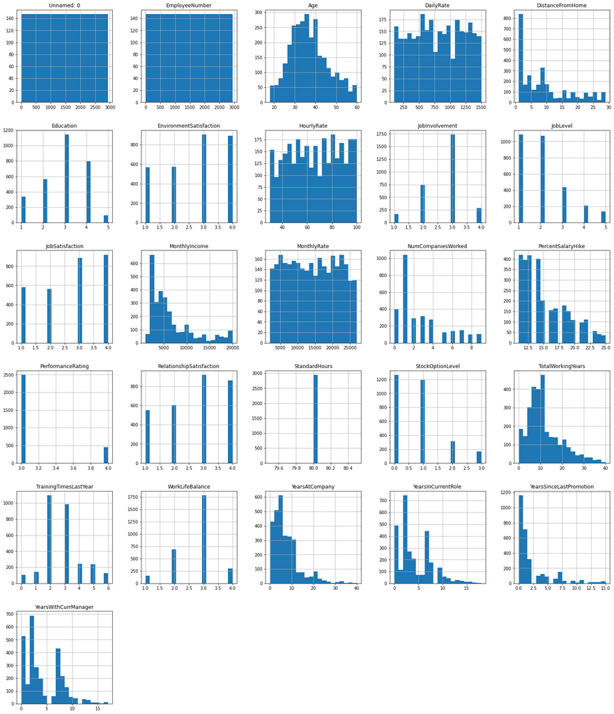

```python
df.hist(figsize = (25,30), bins=20)
```

```python
basicstats = df.describe().T
basicstats['iqr'] = (basicstats['75%'] - basicstats['25%'])
basicstats
```

|  | count | mean | std | min | 25% | 50% | 75% | max | iqr |
| --- | --- | --- | --- | --- | --- | --- | --- | --- | --- |
| Unnamed: 0 | 2940.0 | 1469.500000 | 848.849221 | 0.0 | 734.75 | 1469.5 | 2204.25 | 2939.0 | 1469.5 |
| EmployeeNumber | 2940.0 | 1470.500000 | 848.849221 | 1.0 | 735.75 | 1470.5 | 2205.25 | 2940.0 | 1469.5 |
| Age | 2940.0 | 36.923810 | 9.133819 | 18.0 | 30.00 | 36.0 | 43.00 | 60.0 | 13.0 |
| DailyRate | 2940.0 | 802.485714 | 403.440447 | 102.0 | 465.00 | 802.0 | 1157.00 | 1499.0 | 692.0 |
| DistanceFromHome | 2940.0 | 9.192517 | 8.105485 | 1.0 | 2.00 | 7.0 | 14.00 | 29.0 | 12.0 |
| Education | 2940.0 | 2.912925 | 1.023991 | 1.0 | 2.00 | 3.0 | 4.00 | 5.0 | 2.0 |
| EnvironmentSatisfaction | 2940.0 | 2.721769 | 1.092896 | 1.0 | 2.00 | 3.0 | 4.00 | 4.0 | 2.0 |
| HourlyRate | 2940.0 | 65.891156 | 20.325969 | 30.0 | 48.00 | 66.0 | 84.00 | 100.0 | 36.0 |
| JobInvolvement | 2940.0 | 2.729932 | 0.711440 | 1.0 | 2.00 | 3.0 | 3.00 | 4.0 | 1.0 |
| JobLevel | 2940.0 | 2.063946 | 1.106752 | 1.0 | 1.00 | 2.0 | 3.00 | 5.0 | 2.0 |
| JobSatisfaction | 2940.0 | 2.728571 | 1.102658 | 1.0 | 2.00 | 3.0 | 4.00 | 4.0 | 2.0 |
| MonthlyIncome | 2940.0 | 6502.931293 | 4707.155770 | 1009.0 | 2911.00 | 4919.0 | 8380.00 | 19999.0 | 5469.0 |
| MonthlyRate | 2940.0 | 14313.103401 | 7116.575021 | 2094.0 | 8045.00 | 14235.5 | 20462.00 | 26999.0 | 12417.0 |
| NumCompaniesWorked | 2940.0 | 2.693197 | 2.497584 | 0.0 | 1.00 | 2.0 | 4.00 | 9.0 | 3.0 |
| PercentSalaryHike | 2940.0 | 15.209524 | 3.659315 | 11.0 | 12.00 | 14.0 | 18.00 | 25.0 | 6.0 |
| PerformanceRating | 2940.0 | 3.153741 | 0.360762 | 3.0 | 3.00 | 3.0 | 3.00 | 4.0 | 0.0 |
| RelationshipSatisfaction | 2940.0 | 2.712245 | 1.081025 | 1.0 | 2.00 | 3.0 | 4.00 | 4.0 | 2.0 |
| StandardHours | 2940.0 | 80.000000 | 0.000000 | 80.0 | 80.00 | 80.0 | 80.00 | 80.0 | 0.0 |
| StockOptionLevel | 2940.0 | 0.793878 | 0.851932 | 0.0 | 0.00 | 1.0 | 1.00 | 3.0 | 1.0 |
| TotalWorkingYears | 2940.0 | 11.279592 | 7.779458 | 0.0 | 6.00 | 10.0 | 15.00 | 40.0 | 9.0 |
| TrainingTimesLastYear | 2940.0 | 2.799320 | 1.289051 | 0.0 | 2.00 | 3.0 | 3.00 | 6.0 | 1.0 |
| WorkLifeBalance | 2940.0 | 2.761224 | 0.706356 | 1.0 | 2.00 | 3.0 | 3.00 | 4.0 | 1.0 |
| YearsAtCompany | 2940.0 | 7.008163 | 6.125483 | 0.0 | 3.00 | 5.0 | 9.00 | 40.0 | 6.0 |
| YearsInCurrentRole | 2940.0 | 4.229252 | 3.622521 | 0.0 | 2.00 | 3.0 | 7.00 | 18.0 | 5.0 |
| YearsSinceLastPromotion | 2940.0 | 2.187755 | 3.221882 | 0.0 | 0.00 | 1.0 | 3.00 | 15.0 | 3.0 |
| YearsWithCurrManager | 2940.0 | 4.123129 | 3.567529 | 0.0 | 2.00 | 3.0 | 7.00 | 17.0 | 5.0 |

Mengecek data kategoris berdasarkan value counts

```python
for x in df.select_dtypes(include=[object]).columns:
    print(f'Value In {x}: ', df[x].unique(), '\n', 'Total Value:', len(df[x].unique()))
    print('-'*100)
```

```
Value In Attrition:  ['Yes' 'No']
 Total Value: 2
----------------------------------------------------------------------------------------------------
Value In BusinessTravel:  ['Travel_Rarely' 'Travel_Frequently' 'Non-Travel']
 Total Value: 3
----------------------------------------------------------------------------------------------------
Value In Department:  ['Sales' 'Research & Development' 'Human Resources']
 Total Value: 3
----------------------------------------------------------------------------------------------------
Value In EducationField:  ['Life Sciences' 'Other' 'Medical' 'Marketing' 'Technical Degree'
 'Human Resources']
 Total Value: 6
----------------------------------------------------------------------------------------------------
Value In Gender:  ['Female' 'Male']
 Total Value: 2
----------------------------------------------------------------------------------------------------
Value In JobRole:  ['Sales Executive' 'Research Scientist' 'Laboratory Technician'
 'Manufacturing Director' 'Healthcare Representative' 'Manager'
 'Sales Representative' 'Research Director' 'Human Resources']
 Total Value: 9
----------------------------------------------------------------------------------------------------
Value In MaritalStatus:  ['Single' 'Married' 'Divorced']
 Total Value: 3
----------------------------------------------------------------------------------------------------
Value In Over18:  ['Y']
 Total Value: 1
----------------------------------------------------------------------------------------------------
Value In OverTime:  ['Yes' 'No']
 Total Value: 2
----------------------------------------------------------------------------------------------------
```

Dari data di atas, pembagian data numerikal dan kategorikal antara lain:

1. Kategorikal
   - Education
   - EnvironmentSatisfaction
   - JobInvolvement
   - JobLevel
   - JobSatisfaction
   - PerformanceRating
   - RelationshipSatisfaction
   - StockOptionLevel
   - WorkLifeBalance
   - BusinessTravel
   - Department
   - EducationField
   - Gender
   - JobRole
   - MaritalStatus
   - OverTime
2. Numerikal
   - Age
   - DailyRate
   - DistanceFromHome
   - HourlyRate
   - MonthlyIncome
   - MonthlyRate
   - NumCompaniesWorked
   - PercentSalaryHike
   - TotalWorkingYears
   - TrainingTimesLastYear
   - YearsAtCompany
   - YearsInCurrentRole
   - YearsSinceLastPromotion
   - YearsWithCurManager

dari sini, kolom yang bisa di drop yaitu:

- Unnamed : karena hanya berupa indexing
- EmployeeNumber : karena berupa indexing
- StandardHours : karena hanya berisi 1 value yaitu `80`
- Over18 : karena hanya berisi 1 value

Menghapus kolom-kolom yang tidak diperlukan:

```python
# menghapus kolom yang tidak diperlukan
df.drop(['Unnamed: 0', 'EmployeeNumber', 'StandardHours', 'Over18'], axis=1, inplace=True)

# menentukan kolom kategorikal dan numerikal untuk memudahkan pengolahan
categoricals = ['Attrition', 'Education','EnvironmentSatisfaction','JobInvolvement','JobLevel','JobSatisfaction','PerformanceRating','RelationshipSatisfaction', 'StockOptionLevel', 'WorkLifeBalance', 'BusinessTravel', 'Department', 'EducationField', 'Gender', 'JobRole', 'MaritalStatus', 'OverTime']
numericals = ['Age','DailyRate','DistanceFromHome','HourlyRate','MonthlyIncome','MonthlyRate',
              'PercentSalaryHike','TotalWorkingYears','YearsAtCompany','YearsInCurrentRole','YearsSinceLastPromotion','YearsWithCurrManager']
columns = df.columns
```

## **BOXPLOT**

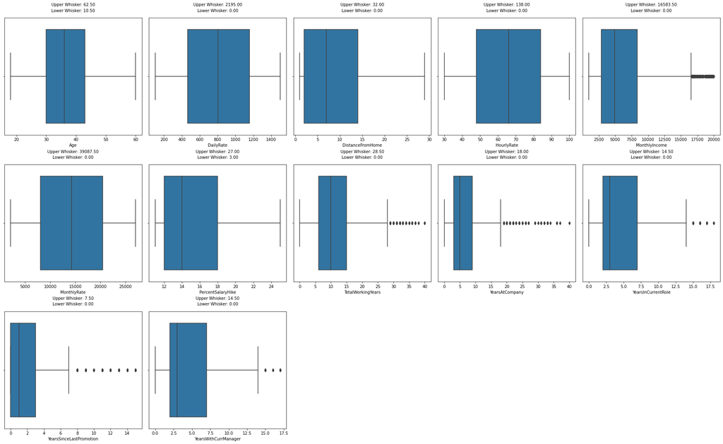

```python
cols = 5
rows = 6
num_cols = numericals
fig = plt.figure(figsize=(cols*5, rows*5))

for i, col in enumerate(num_cols):
    ax = fig.add_subplot(rows, cols, i+1)
    sns.boxplot(x=df[col], ax=ax)
    q1 = df[col].quantile(0.25)
    q3 = df[col].quantile(0.75)
    iqr = q3 - q1
    upper_whisker = q3 + 1.5 * iqr
    lower_whisker = lower_whisker = max(q1 - 1.5 * iqr, 0)

    ax.text(0.5, 1.1, f"Upper Whisker: {upper_whisker:.2f}", transform=ax.transAxes, ha='center')
    ax.text(0.5, 1.05, f"Lower Whisker: {lower_whisker:.2f}", transform=ax.transAxes, ha='center')

fig.tight_layout()
plt.show()
```

Terilahat ada beberapa outlier dari diagram boxplot. Untuk memastikan outlier, akan dilakukan melalui metode pengecekan normalisasi dan IQR

```python
def outlier_analysis(df,col):
  skewness = df[col].skew()
  if skewness>=-0.5 and skewness<=0.5:
    upper = df[col].mean() + 3*df[col].std()
    lower = df[col].mean() - 3*df[col].std()
  else:
    Q1 = df[col].quantile(0.25)
    Q3 = df[col].quantile(0.75)
    IQR = Q3 - Q1

    upper = Q3 + (3 * IQR)
    lower = Q1 - (3 * IQR)

  no_outliers = df[(df[col]>=lower) &  (df[col]<=upper)]
  outliers = df[(df[col]<lower) | (df[col]>upper)]

  return outliers,no_outliers, upper, lower

cols_name = numericals

for i in cols_name:
    out,no_out, up, low = outlier_analysis (df,i)
    print('-'*20)
    print(i)
    print('count of outlier: ', len(out))
    print('proportions: ', (len(out)/len(df))*100, '%')
    print('Skewness :', df[i].skew())
```

```
--------------------
Age
count of outlier:  0
proportions:  0.0 %
Skewness : 0.4130752440991015
--------------------
DailyRate
count of outlier:  0
proportions:  0.0 %
Skewness : -0.003516771483806927
--------------------
DistanceFromHome
count of outlier:  0
proportions:  0.0 %
Skewness : 0.957628702316063
--------------------
HourlyRate
count of outlier:  0
proportions:  0.0 %
Skewness : -0.03229445228762344
--------------------
MonthlyIncome
count of outlier:  0
proportions:  0.0 %
Skewness : 1.3691171405078755
--------------------
MonthlyRate
count of outlier:  0
proportions:  0.0 %
Skewness : 0.01856832054434602
--------------------
PercentSalaryHike
count of outlier:  0
proportions:  0.0 %
Skewness : 0.8207086405356568
--------------------
TotalWorkingYears
count of outlier:  0
proportions:  0.0 %
Skewness : 1.1166013335756102
--------------------
YearsAtCompany
count of outlier:  38
proportions:  1.292517006802721 %
Skewness : 1.76362834141509
--------------------
YearsInCurrentRole
count of outlier:  0
proportions:  0.0 %
Skewness : 0.9168946757013059
--------------------
YearsSinceLastPromotion
count of outlier:  64
proportions:  2.1768707482993195 %
Skewness : 1.9832766427416215
--------------------
YearsWithCurrManager
count of outlier:  0
proportions:  0.0 %
Skewness : 0.8330253638102632
```

```python
col = ['YearsAtCompany', 'YearsSinceLastPromotion']
for i in col:
    upper_1 = df[i].mean() + 3*df[i].std()
    lower_1 = df[i].mean() - 3*df[i].std()
    print(i+':')
    print(df[(df[i]>upper_1) & (df[i]>lower_1)][i].array)
    print(' ')
```

```
YearsAtCompany:
<PandasArray>
[27, 37, 40, 33, 33, 36, 29, 27, 31, 32, 34, 26, 31, 31, 26, 32, 26, 33, 29,
 33, 32, 33, 36, 26, 30, 27, 37, 40, 33, 33, 36, 29, 27, 31, 32, 34, 26, 31,
 31, 26, 32, 26, 33, 29, 33, 32, 33, 36, 26, 30]
Length: 50, dtype: int64

YearsSinceLastPromotion:
<PandasArray>
[15, 13, 12, 12, 15, 15, 15, 12, 15, 13, 12, 15, 13, 12, 14, 13, 14, 15, 15,
 13, 13, 15, 13, 15, 14, 15, 15, 15, 12, 14, 13, 13, 12, 14, 14, 14, 12, 13,
 14, 14, 12, 12, 15, 13, 12, 12, 15, 15, 15, 12, 15, 13, 12, 15, 13, 12, 14,
 13, 14, 15, 15, 13, 13, 15, 13, 15, 14, 15, 15, 15, 12, 14, 13, 13, 12, 14,
 14, 14, 12, 13, 14, 14, 12, 12]
Length: 84, dtype: int64
```

> **Insight:**

**(2) Lakukan EDA univariat untuk setiap kolom kategorikal pada employee.csv yang mencakup:**

a. countplot untuk tiap kolom  
b. daftar kategori unik dan frekuensinya untuk tiap kolom  
c. identifikasi hal yang menurut anda menarik dari hasil EDA yang Anda dapatkan

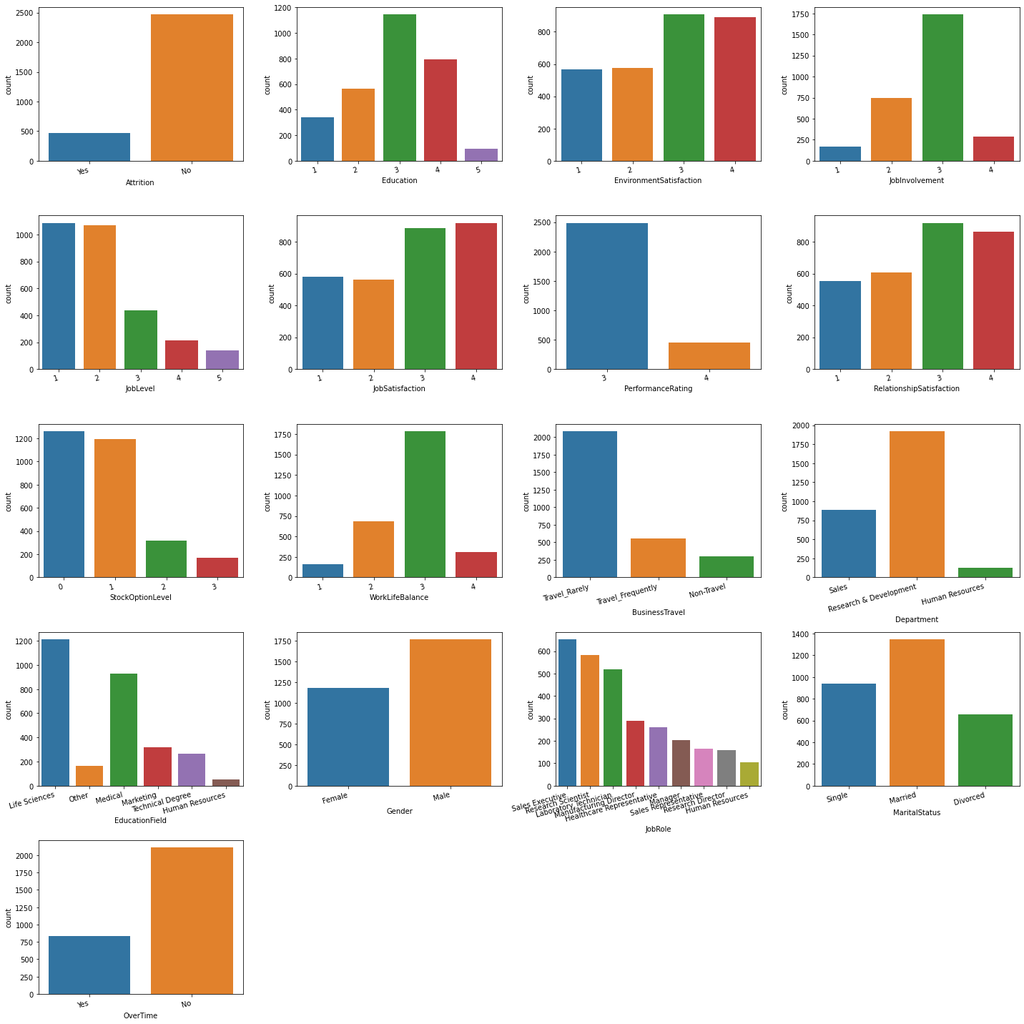

```python
cols = 4
rows = 5
fig = plt.figure(figsize= (20,20))
all_cat = df[categoricals]
cat_cols = df[categoricals].columns

for i, col in enumerate(cat_cols):
    ax=fig.add_subplot(rows, cols, i+1)
    sns.countplot(x=df[col], ax=ax)
    plt.xticks(rotation=15, ha='right')

fig.tight_layout()
plt.show()
```

> **Insight:**
1. Attrition rate di perusahaan ini sangatlah rendah.
2. Karyawan didominasi lulusan sarjana (kategori 3)
3. Keterlibatan karyawan dalam pekerjaan terdapat di kategori 3 (High) yang berarti optimisasi tenaga sumber daya manusianya digunakan dengan baik.
4. Performance rating karyawan didominasi oleh kategori 3 (High) dengan kata lain, pemanfaatan sumber daya manusia di perusahaan ini berjalan efektif dan efisien
5. Work Life Balance para karyawan juga tergolong baik (High)
6. Perusahaan ini didominasi oleh department Research & Development. Dengan kata lain, dapat dimungkinkan perusahaan ini berfokus pada kualitas produk.
7. Dilihat dari education field yang didominasi oleh Medical dan Life Science, dimungkinkan perusahaan ini bergerak di bidang kesehatan.
8. Over Time didominasi oleh 'No'. Bisa dikatakan, pembagian kerja dan pemanfaatan sumber daya sangatlah evisien sehingga tidak terlalu sering terjadi Over Time.

**(3) Lakukan EDA multivariat untuk pasangan kolom numerik dan kolom 'Attrition' pada employee.csv yang mencakup:**

a. boxplot (atau variasinya) antara semua kolom numerik (axis y) dan kolom 'attrition' (axis x)  
b. identifikasi hal yang menurut anda menarik dari hasil EDA yang Anda dapatkan

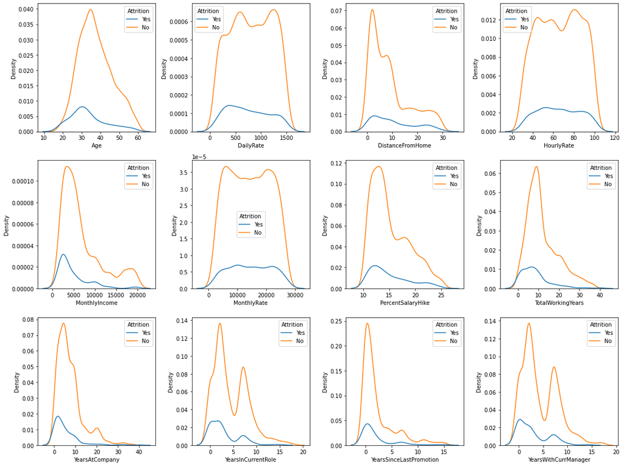

```python
cols = 4
rows = 3
num_cols = df[numericals].columns
fig = plt.figure( figsize=(cols*4, rows*4))

for i, col in enumerate(num_cols):
    ax=fig.add_subplot(rows,cols,i+1)
    sns.kdeplot(x = df[col], hue=df['Attrition'], ax = ax)

fig.tight_layout()
plt.show()
```

Selanjutnya akan digunakan F-test untuk menguji kelayakan feature. F-test digunakan untuk memeriksa keberartian dari setiap fitur dalam membedakan kelompok yang berbeda atau dalam memprediksi variabel target. Nilai F-statistik yang besar menunjukkan perbedaan yang signifikan antara kelompok dan menunjukkan bahwa fitur yang diuji mungkin berguna dalam membedakan kelompok atau memprediksi variabel target. F-test biasa digunakan untuk feature numerical ke target categorical

```python
from sklearn.feature_selection import f_classif

X = df[numericals]
y = df['Attrition']

f_scores, p_values = f_classif(X, y)

for i in range(len(numericals)):
    print(numericals[i])
    print('F-score=%.2f, p-value=%.3f' % (f_scores[i], p_values[i]))
    if p_values[i] > 0.05:
        print('Probably not important')
    else:
        print('Probably important')
    print('-'*20)
```

```
Age
F-score=76.40, p-value=0.000
Probably important
--------------------
DailyRate
F-score=9.46, p-value=0.002
Probably important
--------------------
DistanceFromHome
F-score=17.95, p-value=0.000
Probably important
--------------------
HourlyRate
F-score=0.14, p-value=0.711
Probably not important
--------------------
MonthlyIncome
F-score=77.03, p-value=0.000
Probably important
--------------------
MonthlyRate
F-score=0.68, p-value=0.411
Probably not important
--------------------
PercentSalaryHike
F-score=0.53, p-value=0.465
Probably not important
--------------------
TotalWorkingYears
F-score=88.57, p-value=0.000
Probably important
--------------------
YearsAtCompany
F-score=54.04, p-value=0.000
Probably important
--------------------
YearsInCurrentRole
F-score=77.73, p-value=0.000
Probably important
--------------------
YearsSinceLastPromotion
F-score=3.21, p-value=0.073
Probably not important
--------------------
YearsWithCurrManager
F-score=73.47, p-value=0.000
Probably important
--------------------
```

> **Insight:**

Fitur-fitur berikut memiliki skor-F lebih besar dari nilai kritis dan nilai-p kurang dari 0,05, yang menunjukkan bahwa fitur-fitur tersebut cenderung menjadi prediktor yang signifikan terhadap Attrition. Dengan kata lain, fitur ini memiliki signifikansi terhadap Attrition:

- `Age`
- `DailyRate`
- `DistanceFromHome`
- `MonthlyIncome`
- `TotalWorkingYears`
- `YearsAtCompany`
- `YearsInCurrentRole`
- `YearsWithCurrManager`

Oleh karena itu, jika ingin membuat model klasifikasi terhadap Attrition, maka fitur berikut akan didrop:

- `HourlyRate`
- `MonthlyRate`
- `PercentSalaryHike`
- `YearsSinceLastPromotion`

**(4) Lakukan EDA multivariat untuk pasangan kolom kategorikal dan kolom 'Attrition' pada employee.csv yang mencakup:**

a. countplot untuk tiap kolom kategorikal dengan kolom 'Attrition' sebagai hue  
b. stacked barplot yang menunjukkan proporsi value kolom 'Attrition' untuk masing-masing kategori pada semua kolom kategorikal (1 kolom kategorikal 1 plot, 1 plot berisi stacked bar sejumlah banyaknya kategori unik pada kolom kategori tersebut)  
c. identifikasi hal yang menurut anda menarik dari hasil EDA yang Anda dapatkan

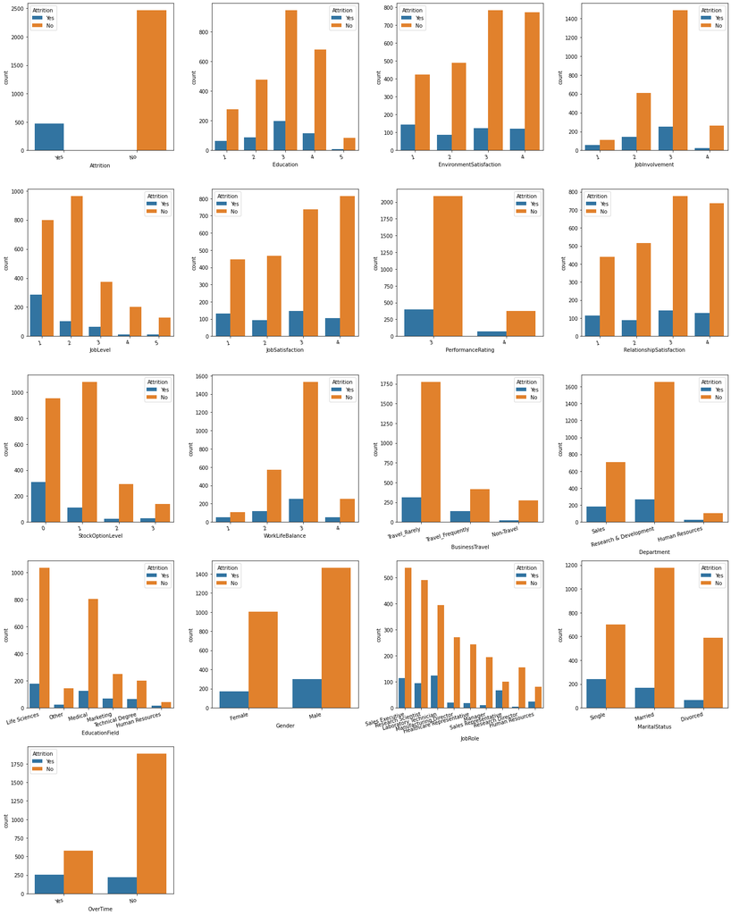

```python
cols = 4
rows = 5
fig = plt.figure(figsize= (20,25))
all_cat = df[categoricals]
cat_cols = df[categoricals].columns

for i, col in enumerate(cat_cols):
    ax=fig.add_subplot(rows, cols, i+1)
    sns.countplot(x=df[col], hue=df['Attrition'], ax=ax)
    plt.xticks(rotation=15, ha='right')

fig.tight_layout()
plt.show()
```

Untuk mengetahui korelasi antara feature kategoris, akan dilakukan pengujian Chi square. Chi-square digunakan untuk menguji hubungan antara setiap fitur dan variabel target dalam data kategori. Semakin kecil nilai p-value, semakin tinggi tingkat signifikansi hasil pengujian statistik tersebut. Chi-Square biasanya digunakan untuk feature categorical ke target categorical.

```python
from scipy.stats import chi2_contingency

for col in categoricals:
    contingency_table = pd.crosstab(df[col], df["Attrition"])
    stat, p, dof, expected = chi2_contingency(contingency_table)
    print(col)
    print('p=%.3f' % (p))
    if p > 0.05:
        print('Probably independent')
    else:
        print('Probably dependent')
    print('-'*20)
```

```
Attrition
p=0.000
Probably dependent
--------------------
Education
p=0.188
Probably independent
--------------------
EnvironmentSatisfaction
p=0.000
Probably dependent
--------------------
JobInvolvement
p=0.000
Probably dependent
--------------------
JobLevel
p=0.000
Probably dependent
--------------------
JobSatisfaction
p=0.000
Probably dependent
--------------------
PerformanceRating
p=0.931
Probably independent
--------------------
RelationshipSatisfaction
p=0.015
Probably dependent
--------------------
StockOptionLevel
p=0.000
Probably dependent
--------------------
WorkLifeBalance
p=0.000
Probably dependent
--------------------
```

[output cut: 13 more lines]

```
p=0.122
Probably independent
--------------------
JobRole
p=0.000
Probably dependent
--------------------
MaritalStatus
p=0.000
Probably dependent
--------------------
OverTime
p=0.000
Probably dependent
--------------------
```

> **Insight:**

Berdasarkan nilai Pvalue-nya, kolom `Education`, `PerformanceRating`, `Gender` tidak memiliki korelasi yang signifikan dengan `Attrition`.

**(5) Lakukan independen t-test (2-sided) dengan ketentuan:**

H0: Tidak ada perbedaan mean 'Total Working Years' antara karyawan yang keluar maupun menetap (gunakan kolom 'Attrition' sebagai acuan)

H1: Terdapat perbedaan mean 'Total Working Years' antara karyawan yang keluar maupun menetap (gunakan kolom 'Attrition' sebagai acuan)

alpha = 5%

Print hasil t-test dan tuliskan kesimpulannya.

```python
from scipy.stats import ttest_ind

# Split data based on Attrition
attrition_yes = df[df['Attrition'] == 'Yes']['TotalWorkingYears']
attrition_no = df[df['Attrition'] == 'No']['TotalWorkingYears']

# Independent t-test
alpha = 0.05
t_statistic, p_value = ttest_ind(attrition_yes, attrition_no)

print("t-statistic:", t_statistic)
print("p-value:", p_value)

if p_value < alpha:
    print("Tolak hipotesis null. Ada perbedaan yang signifikan dalam rata-rata Total Tahun Kerja antara kelompok Attrition.")
else:
    print("Gagal menolak hipotesis nol. Tidak ada perbedaan yang signifikan dalam rata-rata Total Tahun Kerja antara kelompok Attrition.")
```

```
t-statistic: -9.410912409729871
p-value: 9.603230829038466e-21
Tolak hipotesis null. Ada perbedaan yang signifikan dalam rata-rata Total Tahun Kerja antara kelompok Attrition.
```

**(6) Lakukan one-way ANOVA dengan ketentuan:**

H0: Tidak ada perbedaan mean 'Age' antara karyawan dari 3 departemen yang ada di dataset

H1: Setidaknya terdapat 2 departemen yang mean umur karyawannya berbeda

Print hasil one-way ANOVA dan tuliskan kesimpulannya.

```python
from scipy.stats import f_oneway

sales = df[df['Department'] == 'Sales']['Age']
research = df[df['Department'] == 'Research & Development']['Age']
hr = df[df['Department'] == 'Human Resources']['Age']

# One-way ANOVA
alpha = 0.05
f_statistic, p_value = f_oneway(sales, research, hr)

print("f-statistic:", f_statistic)
print("p-value:", p_value)

if p_value < alpha:
    print("Tolak hipotesis null. Ada perbedaan yang signifikan dalam usia rata-rata antar departemen.")
else:
    print("Gagal menolak hipotesis nol. Tidak ada perbedaan yang signifikan dalam usia rata-rata antar departemen.")
```

```
f-statistic: 1.5325718311968073
p-value: 0.21615216157151168
Gagal menolak hipotesis nol. Tidak ada perbedaan yang signifikan dalam usia rata-rata antar departemen.
```

# Classification

**(8) Persiapkan dataset untuk klasifikasi. Jadikan kolom 'Attrition' sebagai target (y). Drop semua kolom yang dianggap tidak diperlukan.**

Berdasarkan analisis bivariate sebelumnya, berikut adalah kolom yang akan didrop:

- `Education`
- `PerformanceRating`
- `Gender`
- `YearsSinceLastPromotion`
- `PercentSalaryHike`
- `MonthlyRate`
- `HourlyRate`

```python
# mengubah attrition menjadi numerik
df_clas = df.copy()
df_clas['Attrition'] = df_clas['Attrition'].str.replace('Yes', '1')
df_clas['Attrition'] = df_clas['Attrition'].str.replace('No', '0')
df_clas['Attrition'] = df_clas['Attrition'].astype(int)
df_clas['Attrition'].head(3)
```

```
0    1
1    0
2    1
Name: Attrition, dtype: int64
```

```python
# dropping kolom yang tidak diperlukan
df_clas = df_clas.drop(['Education', 'PerformanceRating', 'Gender', 'YearsSinceLastPromotion', 'PercentSalaryHike', 'MonthlyRate', 'HourlyRate'], axis=1)

# menetapkan X dan y
X = df_clas.drop(['Attrition'], axis=1)
y = df_clas['Attrition']

print(X.shape)
print(y.shape)
```

```
(2940, 23)
(2940,)
```

**(9) Lakukan train test split, test:test = 4:1, stratify = y.**

```python
from sklearn.model_selection import train_test_split

# membagi data test dan data train
X_train, X_test, y_train, y_test = train_test_split(X, y, test_size=0.2, stratify=y, random_state=42)

print('Train Set')
print(X_train.shape)
print(y_train.shape)
print(' ')
print('Test Set')
print(X_test.shape)
print(y_test.shape)
```

```
Train Set
(2352, 23)
(2352,)

Test Set
(588, 23)
(588,)
```

**(10) Lakukan feature engineering yang dianggap diperlukan pada trainset: imputation, encoding, scaling, selection, dll. Lakukan transformasi serupa pada testset tanpa melakukan fitting kembali.**

```python
for x in X_train.select_dtypes(include=object).columns:
    print(f'Value In {x}: ', df[x].unique(), '\n', 'Total Value:', len(df[x].unique()))
    print('-'*100)
```

```
Value In BusinessTravel:  ['Travel_Rarely' 'Travel_Frequently' 'Non-Travel']
 Total Value: 3
----------------------------------------------------------------------------------------------------
Value In Department:  ['Sales' 'Research & Development' 'Human Resources']
 Total Value: 3
----------------------------------------------------------------------------------------------------
Value In EducationField:  ['Life Sciences' 'Other' 'Medical' 'Marketing' 'Technical Degree'
 'Human Resources']
 Total Value: 6
----------------------------------------------------------------------------------------------------
Value In JobRole:  ['Sales Executive' 'Research Scientist' 'Laboratory Technician'
 'Manufacturing Director' 'Healthcare Representative' 'Manager'
 'Sales Representative' 'Research Director' 'Human Resources']
 Total Value: 9
----------------------------------------------------------------------------------------------------
Value In MaritalStatus:  ['Single' 'Married' 'Divorced']
 Total Value: 3
----------------------------------------------------------------------------------------------------
Value In OverTime:  ['Yes' 'No']
 Total Value: 2
----------------------------------------------------------------------------------------------------
```

Karena data kategorikal didominasi oleh kategori yang tidak memiliki urutan, maka jenis encoder yang akan dipilih adalah OneHotEncoder.

```python
from sklearn.compose import ColumnTransformer
from sklearn.preprocessing import OneHotEncoder
from sklearn.pipeline import Pipeline

# Categorical columns to be one-hot encoded
cat_cols = ['BusinessTravel', 'Department', 'EducationField', 'JobRole', 'MaritalStatus', 'OverTime']

# Define the pipeline
pipeline = Pipeline([
    ('onehot', ColumnTransformer(transformers=[
        ('cat', OneHotEncoder(), cat_cols)
    ], remainder='passthrough'))
])

# Fit and transform the data
X_train_encoded = pipeline.fit_transform(X_train)

pd.DataFrame(X_train_encoded).head(2)
```

|  | 0 | 1 | 2 | 3 | 4 | 5 | 6 | 7 | 8 | 9 | 10 | 11 | 12 | 13 | 14 | 15 | 16 | 17 | 18 | 19 | 20 | 21 | 22 | 23 | 24 | 25 | 26 | 27 | 28 | … |
| --- | --- | --- | --- | --- | --- | --- | --- | --- | --- | --- | --- | --- | --- | --- | --- | --- | --- | --- | --- | --- | --- | --- | --- | --- | --- | --- | --- | --- | --- | --- |
| 0 | 0.0 | 0.0 | 1.0 | 0.0 | 1.0 | 0.0 | 0.0 | 0.0 | 0.0 | 0.0 | 0.0 | 1.0 | 0.0 | 0.0 | 1.0 | 0.0 | 0.0 | 0.0 | 0.0 | 0.0 | 0.0 | 1.0 | 0.0 | 0.0 | 0.0 | 1.0 | 29.0 | 806.0 | 7.0 | … |
| 1 | 0.0 | 0.0 | 1.0 | 0.0 | 1.0 | 0.0 | 0.0 | 0.0 | 0.0 | 0.0 | 1.0 | 0.0 | 0.0 | 0.0 | 0.0 | 0.0 | 0.0 | 0.0 | 1.0 | 0.0 | 0.0 | 1.0 | 0.0 | 0.0 | 1.0 | 0.0 | 39.0 | 835.0 | 19.0 | … |

Sample Attrition tidak seimbang antara 'Yes' dan 'No'. Untuk memaksimalkan kinerja model akan diterapkan SMOTE oversampling agar mendukung tingkat akurasinya.

```python
from imblearn.over_sampling import SMOTE

smote = SMOTE()
X_train_resampled, y_train_resampled = smote.fit_resample(X_train_encoded, y_train)

print(X_train_resampled.shape)
print(y_train_resampled.shape)
```

```
(3946, 43)
(3946,)
```

**(11) Siapkan 3 estimator: lakukan cross-validation dengan estimator Logistic Regression, Decision Tree Classifier, dan XGBoost Classifier (apabila tidak bisa install xgboost silahkan pilih classifier lain untuk menggantikan) untuk menentukan nilai optimal untuk berbagai hyperparameter masing-masing estimator.**

**(12) Fit ketiga estimator dengan trainset. Print classification report untuk trainset dan testset untuk ketiga estimator.**

Dua Pertanyaan ini akan dijawab sebagai berikut:

```python
# encoding X_test dengan pipeline
X_test_encoded = pipeline.transform(X_test)
```

```python
from sklearn.linear_model import LogisticRegression
from sklearn.tree import DecisionTreeClassifier
from xgboost import XGBClassifier
from sklearn.model_selection import GridSearchCV
from sklearn.metrics import classification_report

# Menetapkan estimator dan parameternya
estimators = {
    'Logistic Regression': {
        'model': LogisticRegression(),
        'params': {
            'C': [0.01, 0.1, 1, 10],
            'penalty': ['l1', 'l2']
        }
    },
    'Decision Tree': {
        'model': DecisionTreeClassifier(),
        'params': {
            'max_depth': [2, 4, 6, 8, 10]
        }
    },
    'XGBoost': {
        'model': XGBClassifier(),
        'params': {
            'max_depth': [2, 4, 6],
            'learning_rate': [0.01, 0.1, 1],
            'n_estimators': [50, 100, 150]
        }
    }
}

# Crossval untuk setiap estimator
for name, estimator in estimators.items():
    print(f"-------- Training {name}... --------")
    model = GridSearchCV(estimator['model'], estimator['params'], cv=5, n_jobs=-1)
    model.fit(X_train_resampled, y_train_resampled)
    train_pred = model.predict(X_train_resampled)

    # Printing best parameter tiap estimator
    print(f"Best parameters for {name}:")
    print(model.best_params_)
    print(f"Train Classification report for {name}:")
    print(classification_report(train_pred, y_train_resampled))
    print(' ')

    # Printing classification Report tiap estimator
    print(f" Test Classification report for {name}:")
    test_pred = model.predict(X_test_encoded)
    print(classification_report(y_test, test_pred))
```

```
-------- Training Logistic Regression... --------
Best parameters for Logistic Regression:
{'C': 0.01, 'penalty': 'l2'}
Train Classification report for Logistic Regression:
              precision    recall  f1-score   support

           0       0.72      0.72      0.72      1972
           1       0.72      0.72      0.72      1974

    accuracy                           0.72      3946
   macro avg       0.72      0.72      0.72      3946
weighted avg       0.72      0.72      0.72      3946


 Test Classification report for Logistic Regression:
              precision    recall  f1-score   support

           0       0.90      0.70      0.79       493
           1       0.28      0.60      0.38        95

    accuracy                           0.69       588
   macro avg       0.59      0.65      0.59       588
weighted avg       0.80      0.69      0.72       588

-------- Training Decision Tree... --------
Best parameters for Decision Tree:
{'max_depth': 10}
Train Classification report for Decision Tree:
              precision    recall  f1-score   support

           0       0.97      0.96      0.97      1985
           1       0.96      0.97      0.97      1961

    accuracy                           0.97      3946
   macro avg       0.97      0.97      0.97      3946
weighted avg       0.97      0.97      0.97      3946


 Test Classification report for Decision Tree:
              precision    recall  f1-score   support
```

[output cut: 16 more lines]

```

    accuracy                           1.00      3946
   macro avg       1.00      1.00      1.00      3946
weighted avg       1.00      1.00      1.00      3946


 Test Classification report for XGBoost:
              precision    recall  f1-score   support

           0       0.98      1.00      0.99       493
           1       0.98      0.89      0.93        95

    accuracy                           0.98       588
   macro avg       0.98      0.95      0.96       588
weighted avg       0.98      0.98      0.98       588
```

(13) Dari hasil performansi yang Anda dapatkan manakah estimator yang paling baik?

Model terbaik adalah XGBoost:

Keterangan model lain:

# Regression

**(14) Persiapkan dataset untuk regresi. Jadikan kolom 'MonthlyIncome' sebagai target.**

Pertama, saya harus menyeleksi kolom khusus model regresi. Penyeleksian akan dilakukan menggunakan correlation heatmap.

```python
# membuat copy dataframe khusus model regresi
df_reg = df.copy()

df_reg_cat = df_reg.select_dtypes(include=object)
df_reg_cat.columns
```

```
Index(['Attrition', 'BusinessTravel', 'Department', 'EducationField', 'Gender',
       'JobRole', 'MaritalStatus', 'OverTime'],
      dtype='object')
```

```python
from sklearn.preprocessing import OrdinalEncoder

# melakukan ordinal encoding untuk categorical feature
# hal ini dilakukan untuk melihat correlation heatmap
cat_cols_reg = ['Attrition', 'BusinessTravel', 'Department', 'EducationField', 'Gender', 'JobRole', 'MaritalStatus', 'OverTime']

# Define the pipeline
pipeline_ord = Pipeline([
    ('ordinal', ColumnTransformer(transformers=[
        ('cat', OrdinalEncoder(), cat_cols_reg)
    ], remainder='passthrough'))
])

# Fit and transform the data
df_reg_ord = pipeline_ord.fit_transform(df_reg)
df_reg_ord_frame = pd.DataFrame(df_reg_ord)
df_reg_ord_frame.columns = df_reg.columns
df_reg_ord_frame.head(3)
```

|  | Attrition | Age | BusinessTravel | DailyRate | Department | DistanceFromHome | Education | EducationField | EnvironmentSatisfaction | Gender | HourlyRate | JobInvolvement | JobLevel | JobRole | JobSatisfaction | MaritalStatus | MonthlyIncome | MonthlyRate | NumCompaniesWorked | OverTime | PercentSalaryHike | PerformanceRating | RelationshipSatisfaction | StockOptionLevel | TotalWorkingYears | TrainingTimesLastYear | WorkLifeBalance | YearsAtCompany | YearsInCurrentRole | … |
| --- | --- | --- | --- | --- | --- | --- | --- | --- | --- | --- | --- | --- | --- | --- | --- | --- | --- | --- | --- | --- | --- | --- | --- | --- | --- | --- | --- | --- | --- | --- |
| 0 | 1.0 | 2.0 | 2.0 | 1.0 | 0.0 | 7.0 | 2.0 | 1.0 | 41.0 | 1102.0 | 1.0 | 2.0 | 2.0 | 94.0 | 3.0 | 2.0 | 4.0 | 5993.0 | 19479.0 | 8.0 | 11.0 | 3.0 | 1.0 | 0.0 | 8.0 | 0.0 | 1.0 | 6.0 | 4.0 | … |
| 1 | 0.0 | 1.0 | 1.0 | 1.0 | 1.0 | 6.0 | 1.0 | 0.0 | 49.0 | 279.0 | 8.0 | 1.0 | 3.0 | 61.0 | 2.0 | 2.0 | 2.0 | 5130.0 | 24907.0 | 1.0 | 23.0 | 4.0 | 4.0 | 1.0 | 10.0 | 3.0 | 3.0 | 10.0 | 7.0 | … |
| 2 | 1.0 | 2.0 | 1.0 | 4.0 | 1.0 | 2.0 | 2.0 | 1.0 | 37.0 | 1373.0 | 2.0 | 2.0 | 4.0 | 92.0 | 2.0 | 1.0 | 3.0 | 2090.0 | 2396.0 | 6.0 | 15.0 | 3.0 | 2.0 | 0.0 | 7.0 | 3.0 | 3.0 | 0.0 | 0.0 | … |

> Correlation Analysis

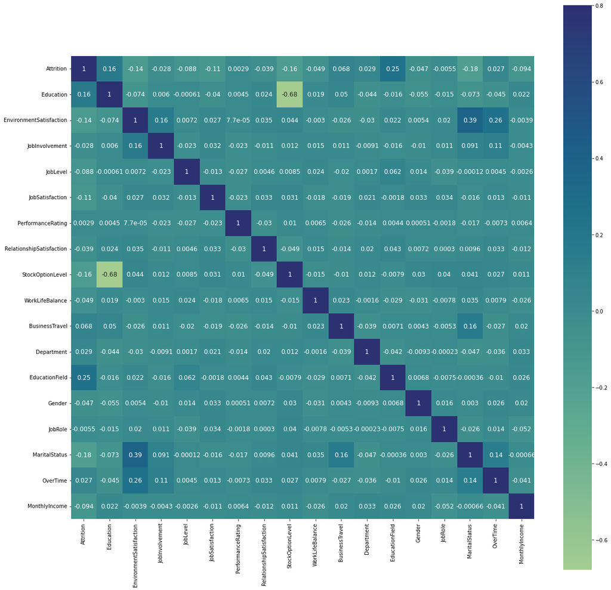

```python
f, ax = plt.subplots(figsize=(20, 20))
sns.heatmap(df_reg_ord_frame[categoricals+['MonthlyIncome']].corr(method='kendall'), vmax=.8, square=True, annot=True, cmap='crest', annot_kws={"fontsize":12});

plt.figure(figsize=(20,20))
plt.show()
```

Korelasi kolom MonthlyIncome dengan kolom kategorical lain sangatlah buruk. Akan sangat sulit mencari fitur kategorikal yang baik untuk memprediksi kolom ini.

Dari feature kategorikal, jika menetapkan correlation score 0.1 kolom yang hanya dapat dijadikan feature adalah `Attrition` (0.094 yang mendekati 0.1)

> Korelasi dengan kolom numerikal

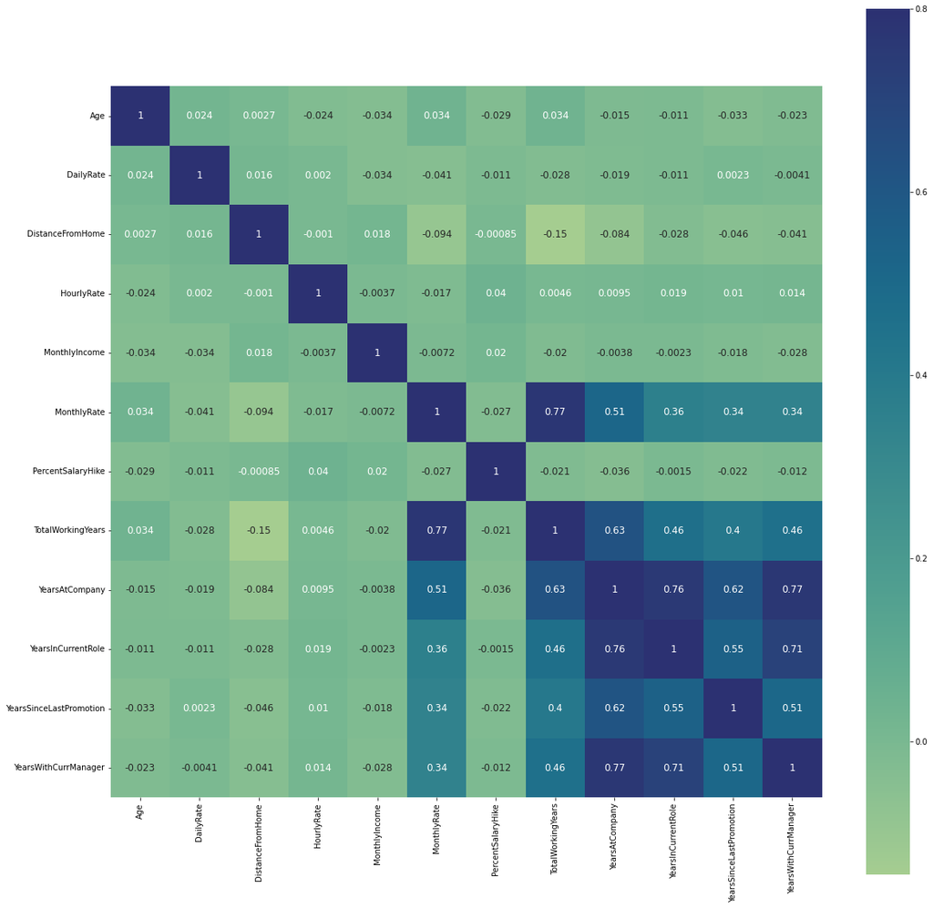

```python
f, ax = plt.subplots(figsize=(20, 20))
sns.heatmap(df_reg_ord_frame[numericals].corr(method='pearson'), vmax=.8, square=True, annot=True, cmap='crest', annot_kws={"fontsize":12});

plt.figure(figsize=(20,20))
plt.show()
```

1. Kemungkinan model regresi MonthlyRate akan memiliki akurasi kurang baik.
2. Ada variabel (kolom) lain yang tidak dicantumkan dalam dataframe.
3. Kemungkinan terakhir, data bersifat sintesis.

Jika melihat hasil dari kedua correlation heatmap, kolom yang akan dijadikan feature terlalu sedikit. Oleh karena itu, feature selection akan digunakan menggunakan intuisi/rasionalisasi.

Kolom lain akan didrop karena beberapa alasan:

1. Secara logika tidak ada korelasinya.
2. Secara logika, valuenya sudah direpresentasikan dengan kolom lain.

**(15) Split trainset dan testset. test size = 0.2.**

```python
df_reg = df_reg[['DailyRate', 'HourlyRate', 'MonthlyRate', 'PercentSalaryHike', 'JobInvolvement', 'JobRole', 'Department', 'TotalWorkingYears', 'OverTime', 'Attrition', 'Education', 'EducationField', 'MonthlyIncome']]
X_reg = df_reg.drop(['MonthlyIncome'], axis=1)
y_reg = df_reg['MonthlyIncome']

# Splitting
X_train_reg, X_test_reg, y_train_reg, y_test_reg = train_test_split(
    X_reg,
    y_reg,
    test_size=0.2,
    random_state=42)

# Pengecekan shape
print('Training Shape')
print(X_train_reg.shape)
print(y_train_reg.shape)
print(' ')
print('Test Shape')
print(X_test_reg.shape)
print(y_test_reg.shape)
```

```
Training Shape
(2352, 12)
(2352,)

Test Shape
(588, 12)
(588,)
```

**(16) Lakukan transformasi yang diperlukan pada trainset. Lakukan juga pada testset tanpa fitting ulang.**

Hal yang akan dilakukan untuk mempersiapkan dataset regresi yaitu:

1. MinMax Scaling untuk kolom numerik.
2. OneHotEncoding untuk kolom kategorikal.
3. Karena kolom yang memiliki outlier sudah didrop dari awal saat feature selection, outlier tidak akan di capping atau di sensor.

```python
print(X_train_reg.select_dtypes(include=int).columns)
print(X_train_reg.select_dtypes(include=object).columns)
```

```
Index(['DailyRate', 'HourlyRate', 'MonthlyRate', 'PercentSalaryHike',
       'JobInvolvement', 'TotalWorkingYears', 'Education'],
      dtype='object')
Index(['JobRole', 'Department', 'OverTime', 'Attrition', 'EducationField'], dtype='object')
```

```python
# buat pipeline untuk normalisasi
pipeline_scaler = Pipeline(steps=[
    ('scaler', MinMaxScaler())
])

# gabungkan pipeline untuk normalisasi dan kategorikal
full_pipeline_reg = ColumnTransformer(transformers=[
    ('num', pipeline_scaler, ['DailyRate', 'HourlyRate', 'MonthlyRate', 'PercentSalaryHike', 'JobInvolvement', 'TotalWorkingYears', 'Education']),
    ('cat', OneHotEncoder(), ['JobRole', 'Department', 'OverTime', 'Attrition', 'EducationField'])
])

# transform data menggunakan pipeline yang telah dibuat
X_train_transformed = full_pipeline_reg.fit_transform(X_train_reg)
pd.DataFrame(X_train_transformed)
```

|  | 0 | 1 | 2 | 3 | 4 | 5 | 6 | 7 | 8 | 9 | 10 | 11 | 12 | 13 | 14 | 15 | 16 | 17 | 18 | 19 | 20 | 21 | 22 | 23 | 24 | 25 | 26 | 27 | 28 |
| --- | --- | --- | --- | --- | --- | --- | --- | --- | --- | --- | --- | --- | --- | --- | --- | --- | --- | --- | --- | --- | --- | --- | --- | --- | --- | --- | --- | --- | --- |
| 0 | 0.419470 | 0.200000 | 0.931419 | 0.714286 | 0.333333 | 0.250 | 0.50 | 0.0 | 0.0 | 0.0 | 1.0 | 0.0 | 0.0 | 0.0 | 0.0 | 0.0 | 0.0 | 0.0 | 1.0 | 1.0 | 0.0 | 1.0 | 0.0 | 0.0 | 1.0 | 0.0 | 0.0 | 0.0 | 0.0 |
| 1 | 0.111668 | 0.628571 | 0.715800 | 0.071429 | 1.000000 | 0.250 | 0.75 | 0.0 | 0.0 | 0.0 | 0.0 | 0.0 | 0.0 | 0.0 | 1.0 | 0.0 | 0.0 | 0.0 | 1.0 | 1.0 | 0.0 | 1.0 | 0.0 | 0.0 | 1.0 | 0.0 | 0.0 | 0.0 | 0.0 |
| 2 | 0.558339 | 0.885714 | 0.189440 | 0.142857 | 0.666667 | 0.300 | 0.75 | 0.0 | 0.0 | 0.0 | 0.0 | 0.0 | 0.0 | 0.0 | 1.0 | 0.0 | 0.0 | 0.0 | 1.0 | 1.0 | 0.0 | 1.0 | 0.0 | 0.0 | 1.0 | 0.0 | 0.0 | 0.0 | 0.0 |
| 3 | 0.894059 | 0.714286 | 0.213812 | 0.214286 | 0.666667 | 0.250 | 0.75 | 1.0 | 0.0 | 0.0 | 0.0 | 0.0 | 0.0 | 0.0 | 0.0 | 0.0 | 0.0 | 1.0 | 0.0 | 1.0 | 0.0 | 1.0 | 0.0 | 0.0 | 1.0 | 0.0 | 0.0 | 0.0 | 0.0 |
| 4 | 0.071582 | 0.600000 | 0.615941 | 0.500000 | 0.666667 | 0.025 | 0.00 | 0.0 | 0.0 | 0.0 | 0.0 | 0.0 | 0.0 | 0.0 | 0.0 | 1.0 | 0.0 | 0.0 | 1.0 | 1.0 | 0.0 | 1.0 | 0.0 | 0.0 | 0.0 | 0.0 | 0.0 | 0.0 | 1.0 |
| ... | ... | ... | ... | ... | ... | ... | ... | ... | ... | ... | ... | ... | ... | ... | ... | ... | ... | ... | ... | ... | ... | ... | ... | ... | ... | ... | ... | ... | ... |
| 2347 | 0.429492 | 0.414286 | 0.435093 | 0.785714 | 0.333333 | 0.300 | 0.75 | 0.0 | 0.0 | 0.0 | 0.0 | 0.0 | 0.0 | 0.0 | 1.0 | 0.0 | 0.0 | 0.0 | 1.0 | 1.0 | 0.0 | 1.0 | 0.0 | 0.0 | 1.0 | 0.0 | 0.0 | 0.0 | 0.0 |
| 2348 | 0.348604 | 0.700000 | 0.837382 | 0.071429 | 0.666667 | 0.375 | 0.75 | 0.0 | 0.0 | 1.0 | 0.0 | 0.0 | 0.0 | 0.0 | 0.0 | 0.0 | 0.0 | 1.0 | 0.0 | 0.0 | 1.0 | 1.0 | 0.0 | 0.0 | 1.0 | 0.0 | 0.0 | 0.0 | 0.0 |
| 2349 | 0.463851 | 0.228571 | 0.933708 | 0.428571 | 1.000000 | 0.250 | 0.50 | 0.0 | 0.0 | 1.0 | 0.0 | 0.0 | 0.0 | 0.0 | 0.0 | 0.0 | 0.0 | 1.0 | 0.0 | 1.0 | 0.0 | 1.0 | 0.0 | 0.0 | 1.0 | 0.0 | 0.0 | 0.0 | 0.0 |
| 2350 | 0.246958 | 0.785714 | 0.539490 | 0.071429 | 1.000000 | 0.275 | 0.50 | 1.0 | 0.0 | 0.0 | 0.0 | 0.0 | 0.0 | 0.0 | 0.0 | 0.0 | 0.0 | 1.0 | 0.0 | 1.0 | 0.0 | 1.0 | 0.0 | 0.0 | 1.0 | 0.0 | 0.0 | 0.0 | 0.0 |
| 2351 | 0.826056 | 0.257143 | 0.085485 | 0.000000 | 0.333333 | 0.025 | 0.75 | 0.0 | 0.0 | 0.0 | 0.0 | 0.0 | 0.0 | 1.0 | 0.0 | 0.0 | 0.0 | 1.0 | 0.0 | 0.0 | 1.0 | 0.0 | 1.0 | 0.0 | 1.0 | 0.0 | 0.0 | 0.0 | 0.0 |

2352 rows × 29 columns

**(17) Siapkan 2 regressor learning alg.: (1) linear/polynomial dan (2) decision tree/random forest/xgboost regressor. Dengan menggunakan cross validation tentukan hyperparamer optimal untuk kedua regressor.**

Untuk pertanyaan ini, saya akan mencoba 3 model: polynomial regressor, xgboost, dan decision tree. Hal ini dikarenakan korelasi kolom MonthlyIncome sangatlah buruk, jadi saya akan mencoba algoritma tambahan dengan harapan dapat menghasilkan prediksi yang baik.

**POLYNOMIAL REGRESSOR**

```python
from sklearn.pipeline import make_pipeline
from sklearn.preprocessing import PolynomialFeatures
from sklearn.linear_model import LinearRegression
from sklearn.model_selection import GridSearchCV

polynomial_regression = make_pipeline(PolynomialFeatures(), LinearRegression())
param_grid = {'polynomialfeatures__degree': [1, 2, 3, 4, 5]}

grid_search_linreg = GridSearchCV(polynomial_regression, param_grid, cv=2, scoring='neg_mean_absolute_error')
grid_search_linreg.fit(X_train_transformed, y_train_reg)

print('Best Degree:', grid_search_linreg.best_params_['polynomialfeatures__degree'])
print('Best Score:', -grid_search_linreg.best_score_)
```

```
Best Degree: 1
Best Score: 1313.6921473092311
```

**XGBOOST REGRESSOR**

```python
from xgboost import XGBRegressor

xgb_reg = XGBRegressor()
param_grid = {'n_estimators': [100, 500, 1000],
              'learning_rate': [0.01, 0.1, 0.5],
              'max_depth': [3, 5, 7]}

grid_search_xgbreg = GridSearchCV(xgb_reg, param_grid, cv=5, scoring='neg_mean_absolute_error')
grid_search_xgbreg.fit(X_train_transformed, y_train_reg)

print('Best Estimator:', grid_search_xgbreg.best_estimator_)
print('Best Score:', -grid_search_xgbreg.best_score_)
```

```
Best Estimator: XGBRegressor(base_score=None, booster=None, callbacks=None,
             colsample_bylevel=None, colsample_bynode=None,
             colsample_bytree=None, early_stopping_rounds=None,
             enable_categorical=False, eval_metric=None, feature_types=None,
             gamma=None, gpu_id=None, grow_policy=None, importance_type=None,
             interaction_constraints=None, learning_rate=0.1, max_bin=None,
             max_cat_threshold=None, max_cat_to_onehot=None,
             max_delta_step=None, max_depth=7, max_leaves=None,
             min_child_weight=None, missing=nan, monotone_constraints=None,
             n_estimators=1000, n_jobs=None, num_parallel_tree=None,
             predictor=None, random_state=None, ...)
Best Score: 446.75872592506755
```

**DECISION TREE REGRESSOR**

```python
from sklearn.tree import DecisionTreeRegressor

dtr = DecisionTreeRegressor()

param_grid = {'max_depth': [3, 5, 7, 9],
              'min_samples_split': [2, 4, 6, 8],
              'min_samples_leaf': [1, 2, 3, 4]}

grid_search_dtr = GridSearchCV(dtr, param_grid, cv=5, scoring='neg_mean_absolute_error')
grid_search_dtr.fit(X_train_transformed, y_train_reg)

print('Best Estimator:', grid_search_dtr.best_estimator_)
print('Best Score:', -grid_search_dtr.best_score_)
```

```
Best Estimator: DecisionTreeRegressor(max_depth=9)
Best Score: 985.483741835701
```

**(18) Print metrics r2, mse, rmse, mae, dan mape (dalam bentuk dataframe) trainset vs testset untuk kedua regressor. Manakah model yang lebih baik performance-nya?**

**EVALUATION**

```python
X_test_transformed = full_pipeline_reg.transform(X_test_reg)
```

```python
from sklearn.metrics import r2_score, mean_squared_error, mean_absolute_error

# Predict on the train set
train_pred_reg = grid_search_linreg.predict(X_train_transformed)
train_pred_xgb = grid_search_xgbreg.predict(X_train_transformed)
train_pred_dtr = grid_search_dtr.predict(X_train_transformed)

# Predict on the test set
test_pred_reg = grid_search_linreg.predict(X_test_transformed)
test_pred_xgb = grid_search_xgbreg.predict(X_test_transformed)
test_pred_dtr = grid_search_dtr.predict(X_test_transformed)

# linreg eval train
r2_linreg_train = r2_score(train_pred_reg, y_train)
mse_linreg_train = mean_squared_error(train_pred_reg, y_train)
rmse_linreg_train = mean_squared_error(train_pred_reg, y_train, squared=False)
mae_linreg_train = mean_absolute_error(train_pred_reg, y_train)
mape_linreg_train = (abs(train_pred_reg - y_train) / train_pred_reg).mean() * 100

# linreg eval test
r2_linreg_test = r2_score(test_pred_reg, y_test)
mse_linreg_test = mean_squared_error(test_pred_reg, y_test)
rmse_linreg_test = mean_squared_error(test_pred_reg, y_test, squared=False)
mae_linreg_test = mean_absolute_error(test_pred_reg, y_test)
mape_linreg_test = (abs(test_pred_reg - y_test) / test_pred_reg).mean() * 100

# xgboost eval train
r2_xgb_train = r2_score(train_pred_xgb, y_train)
mse_xgb_train = mean_squared_error(train_pred_xgb, y_train)
rmse_xgb_train = mean_squared_error(train_pred_xgb, y_train, squared=False)
mae_xgb_train = mean_absolute_error(train_pred_xgb, y_train)
mape_xgb_train = (abs(train_pred_xgb - y_train) / train_pred_xgb).mean() * 100

# xgboost eval test
r2_xgb_test = r2_score(test_pred_xgb, y_test)
mse_xgb_test = mean_squared_error(test_pred_xgb, y_test)
rmse_xgb_test = mean_squared_error(test_pred_xgb, y_test, squared=False)
mae_xgb_test = mean_absolute_error(test_pred_xgb, y_test)
mape_xgb_test = (abs(test_pred_xgb - y_test) / test_pred_xgb).mean() * 100

# dtr eval train
r2_dtr_train = r2_score(train_pred_dtr, y_train)
mse_dtr_train = mean_squared_error(train_pred_dtr, y_train)
rmse_dtr_train = mean_squared_error(train_pred_dtr, y_train, squared=False)
mae_dtr_train = mean_absolute_error(train_pred_dtr, y_train)
mape_dtr_train = (abs(train_pred_dtr - y_train) / train_pred_dtr).mean() * 100

#dtr eval test
r2_dtr_test = r2_score(test_pred_dtr, y_test)
mse_dtr_test = mean_squared_error(test_pred_dtr, y_test)
rmse_dtr_test = mean_squared_error(test_pred_dtr, y_test, squared=False)
mae_dtr_test = mean_absolute_error(test_pred_dtr, y_test)
mape_dtr_test = (abs(test_pred_dtr - y_test) / test_pred_dtr).mean() * 100

metrics_df = pd.DataFrame({
    'Prediction':['Train Linreg,', 'Test Linreg', 'Train XGBoost', 'Test XGBoost', 'Train DTR', 'Test DTR'],
    'R^2':[r2_linreg_train, r2_linreg_test, r2_xgb_train, r2_xgb_test, r2_dtr_train, r2_dtr_test],
    'MSE':[mse_linreg_train, mse_linreg_test, mse_xgb_train, mse_xgb_test, mse_dtr_train, mse_dtr_test],
    'RMSE':[rmse_linreg_train, rmse_linreg_test, rmse_xgb_train, rmse_xgb_test, rmse_dtr_train, rmse_dtr_test],
    'MAE': [mae_linreg_train, mae_linreg_test, mae_xgb_train, mae_xgb_test, mae_dtr_train, mae_dtr_test],
    'MAPE': [mape_linreg_train, mape_linreg_test, mape_xgb_train, mape_xgb_test, mape_dtr_train, mape_dtr_test]})

# Display the DataFrame
metrics_df
```

|  | Prediction | R^2 | MSE | RMSE | MAE | MAPE |
| --- | --- | --- | --- | --- | --- | --- |
| 0 | Train Linreg, | -2.188230 | 6.179937e+07 | 7861.257753 | 6512.737245 | 99.996299 |
| 1 | Test Linreg | -2.239752 | 5.937928e+07 | 7705.795055 | 6407.104174 | 99.996579 |
| 2 | Train XGBoost | -1.923099 | 6.447170e+07 | 8029.426913 | 6512.736507 | 99.996163 |
| 3 | Test XGBoost | -1.894577 | 6.311653e+07 | 7944.591428 | 6427.403697 | 99.996450 |
| 4 | Train DTR | -2.044680 | 6.316024e+07 | 7947.341558 | 6512.737245 | 99.996302 |
| 5 | Test DTR | -1.960369 | 6.316810e+07 | 7947.836257 | 6467.629697 | 99.996595 |

Dari hasil evaluasi di atas, kedua model tidak beda jauh, tapi akurasi ketiga model masih sangat buruk. Seperti yang telah ditemukan pada EDA di atas, kolom 'MonthlyIncome' Memiliki korelasi yang buruk dari semua kolom yang ada, sehingga sangat sulit ditetapkan feature yang cocok untuk memprediksi MonthlyIncome.

Hal yang dapat dilakukan untuk meningkatkan performa:

1. Periksa keabsahan data. Karena data yang buruk akan menghasilkan model yang buruk pula.
2. Menggunakan algoritma berbeda.
3. Menggunakan teknik ensemble.
4. Menambahkan fitur baru: Jika ada fitur baru yang dapat memberikan informasi tambahan untuk memprediksi target, hal ini akan sangat bermanfaat. Karena dari fitur-fitur yang ada, sangat sulit untuk memprediksi MonthlyIncome.

Meskipun begitu, jika memilih model mana yang lebih baik, maka model tersebutjatuh kepada **XGBoost** karena memiliki R2 score paling mendekati 1.

# Clustering

**(19) Lakukan transformasi yang diperlukan pada dataset employee**

Dalam clustering, semua feature akan dimasukkan. Langkah selanjutnya, pengecekan outlier dengan Local Outlier Factor untuk mengoptimalkan clustering model.

```python
df.select_dtypes(include=object).columns
```

```
Index(['Attrition', 'BusinessTravel', 'Department', 'EducationField', 'Gender',
       'JobRole', 'MaritalStatus', 'OverTime'],
      dtype='object')
```

```python
# List kolom yang akan dilakukan ordinal encoding
ordinal_cols = ['Attrition', 'BusinessTravel', 'Department', 'EducationField', 'Gender', 'JobRole', 'MaritalStatus', 'OverTime']

# Membuat pipeline
ordinal_pipeline = Pipeline(steps=[('ordinal_encoder', OrdinalEncoder())])

# Melakukan fit transform pada kolom-kolom yang akan dilakukan ordinal encoding
ordinal_transformed = ordinal_pipeline.fit_transform(df[ordinal_cols])
df_clus_transformed = pd.DataFrame(ordinal_transformed, columns=ordinal_cols)

df_clus_num = df.select_dtypes(include=int)
df_clus_full = pd.concat([df_clus_transformed, df_clus_num], axis=1)
df_clus_full
```

|  | Attrition | BusinessTravel | Department | EducationField | Gender | JobRole | MaritalStatus | OverTime | Age | DailyRate | DistanceFromHome | Education | EnvironmentSatisfaction | HourlyRate | JobInvolvement | JobLevel | JobSatisfaction | MonthlyIncome | MonthlyRate | NumCompaniesWorked | PercentSalaryHike | PerformanceRating | RelationshipSatisfaction | StockOptionLevel | TotalWorkingYears | TrainingTimesLastYear | WorkLifeBalance | YearsAtCompany | YearsInCurrentRole | … |
| --- | --- | --- | --- | --- | --- | --- | --- | --- | --- | --- | --- | --- | --- | --- | --- | --- | --- | --- | --- | --- | --- | --- | --- | --- | --- | --- | --- | --- | --- | --- |
| 0 | 1.0 | 2.0 | 2.0 | 1.0 | 0.0 | 7.0 | 2.0 | 1.0 | 41 | 1102 | 1 | 2 | 2 | 94 | 3 | 2 | 4 | 5993 | 19479 | 8 | 11 | 3 | 1 | 0 | 8 | 0 | 1 | 6 | 4 | … |
| 1 | 0.0 | 1.0 | 1.0 | 1.0 | 1.0 | 6.0 | 1.0 | 0.0 | 49 | 279 | 8 | 1 | 3 | 61 | 2 | 2 | 2 | 5130 | 24907 | 1 | 23 | 4 | 4 | 1 | 10 | 3 | 3 | 10 | 7 | … |
| 2 | 1.0 | 2.0 | 1.0 | 4.0 | 1.0 | 2.0 | 2.0 | 1.0 | 37 | 1373 | 2 | 2 | 4 | 92 | 2 | 1 | 3 | 2090 | 2396 | 6 | 15 | 3 | 2 | 0 | 7 | 3 | 3 | 0 | 0 | … |
| 3 | 0.0 | 1.0 | 1.0 | 1.0 | 0.0 | 6.0 | 1.0 | 1.0 | 33 | 1392 | 3 | 4 | 4 | 56 | 3 | 1 | 3 | 2909 | 23159 | 1 | 11 | 3 | 3 | 0 | 8 | 3 | 3 | 8 | 7 | … |
| 4 | 0.0 | 2.0 | 1.0 | 3.0 | 1.0 | 2.0 | 1.0 | 0.0 | 27 | 591 | 2 | 1 | 1 | 40 | 3 | 1 | 2 | 3468 | 16632 | 9 | 12 | 3 | 4 | 1 | 6 | 3 | 3 | 2 | 2 | … |
| ... | ... | ... | ... | ... | ... | ... | ... | ... | ... | ... | ... | ... | ... | ... | ... | ... | ... | ... | ... | ... | ... | ... | ... | ... | ... | ... | ... | ... | ... | … |
| 2935 | 0.0 | 1.0 | 1.0 | 3.0 | 1.0 | 2.0 | 1.0 | 0.0 | 36 | 884 | 23 | 2 | 3 | 41 | 4 | 2 | 4 | 2571 | 12290 | 4 | 17 | 3 | 3 | 1 | 17 | 3 | 3 | 5 | 2 | … |
| 2936 | 0.0 | 2.0 | 1.0 | 3.0 | 1.0 | 0.0 | 1.0 | 0.0 | 39 | 613 | 6 | 1 | 4 | 42 | 2 | 3 | 1 | 9991 | 21457 | 4 | 15 | 3 | 1 | 1 | 9 | 5 | 3 | 7 | 7 | … |
| 2937 | 0.0 | 2.0 | 1.0 | 1.0 | 1.0 | 4.0 | 1.0 | 1.0 | 27 | 155 | 4 | 3 | 2 | 87 | 4 | 2 | 2 | 6142 | 5174 | 1 | 20 | 4 | 2 | 1 | 6 | 0 | 3 | 6 | 2 | … |
| 2938 | 0.0 | 1.0 | 2.0 | 3.0 | 1.0 | 7.0 | 1.0 | 0.0 | 49 | 1023 | 2 | 3 | 4 | 63 | 2 | 2 | 2 | 5390 | 13243 | 2 | 14 | 3 | 4 | 0 | 17 | 3 | 2 | 9 | 6 | … |
| 2939 | 0.0 | 2.0 | 1.0 | 3.0 | 1.0 | 2.0 | 1.0 | 0.0 | 34 | 628 | 8 | 3 | 2 | 82 | 4 | 2 | 3 | 4404 | 10228 | 2 | 12 | 3 | 1 | 0 | 6 | 3 | 4 | 4 | 3 | … |

2940 rows × 31 columns

Melakukan deteksi outlier dengan Local Outlier Factor (LOF) untuk mempermudah klasterisasi.

```python
from sklearn.neighbors import LocalOutlierFactor

lof = LocalOutlierFactor(n_neighbors = 20,contamination=.03)
df_clus_full['lof'] = lof.fit_predict(df_clus_full)
df_clus_full['negative_outlier_factor'] = lof.negative_outlier_factor_
outlier = df_clus_full[df_clus_full['lof'] == -1]
outlier.shape
```

```
(88, 33)
```

```python
df_clus_full = df_clus_full.drop(outlier.index)
df_no_outlier = df.drop(outlier.index)
```

(21) Dengan menggunakan elbow method dan sillhouette score tentukan nilai k optimal untuk pembuatan model kmeans/kmedoids clustering

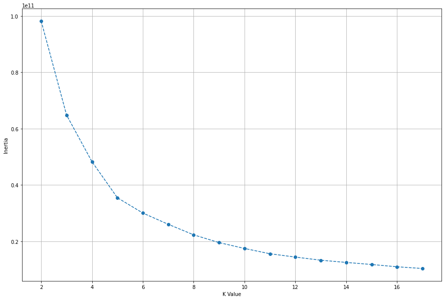

```python
from sklearn.cluster import KMeans

K=[2,3,4,5,6,7,8,9,10,11,12,13,14,15,16,17]
inertia=[KMeans(n_clusters=i).fit(df_clus_full).inertia_ for i in K]

plt.figure(figsize=(15,10))
plt.plot(K,inertia,'o--')
plt.xlabel('K Value')
plt.ylabel('Inertia')
plt.grid()
plt.show()
```

Jika melihat sekilas, garis patahan elbow terletak di KValue=5 atau KValue=6.

Untuk memastikannya, saya akan menggunakan library **kneed** sebagai elbow-locator.

```python
!pip install kneed
```

```python
from kneed import KneeLocator

kn = KneeLocator(K, inertia, curve='convex', direction='decreasing')
print(f'Elbow is located at K = {kn.knee}')
```

```
Elbow is located at K = 5
```

Elbow ada pada K = 5.

Analisis K optimal akan dilanjutkan ke silhouette method.

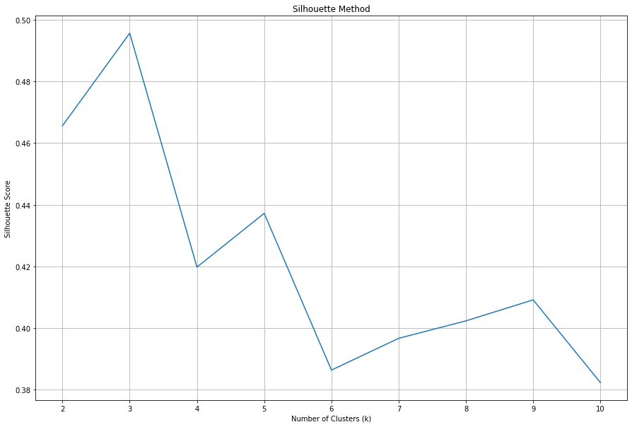

```python
silhouette_scores = []

for i in range(2, 11):
    kmeans = KMeans(n_clusters=i)
    kmeans.fit(df_clus_full)
    silhouette_scores.append(silhouette_score(df_clus_full, kmeans.labels_))

plt.figure(figsize=(15,10))
plt.plot(range(2, 11), silhouette_scores)
plt.title('Silhouette Method')
plt.xlabel('Number of Clusters (k)')
plt.ylabel('Silhouette Score')
plt.grid()
plt.show()
```

Menurut silhouette method, K terbaik terletak pada 3. yaitu yang memiliki inertia paling mendekati 1.

Kemudian saya akan melanjutkan ke silhouette plot.

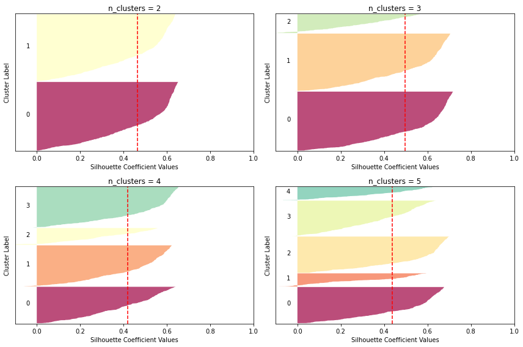

```python
from sklearn.metrics import silhouette_samples, silhouette_score

# Menentukan rentang jumlah cluster yang diinginkan
range_n_clusters = [2, 3, 4, 5]

# Membuat subplot untuk setiap jumlah cluster
fig, axs = plt.subplots(nrows=2, ncols=2, figsize=(12, 8))
axs = axs.flatten()

for i, n_clusters in enumerate(range_n_clusters):
    # Membuat model KMeans dan melakukan pengelompokan
    kmeans = KMeans(n_clusters=n_clusters, random_state=42)
    labels = kmeans.fit_predict(df_clus_full)

    # Menghitung silhouette score
    silhouette_avg = silhouette_score(df_clus_full, labels)

    # Menghitung nilai silhouette untuk setiap sampel
    sample_silhouette_values = silhouette_samples(df_clus_full, labels)

    # Membuat plot
    axs[i].set_xlim([-0.1, 1])
    axs[i].set_ylim([0, len(df_clus_full) + (n_clusters + 1) * 10])
    axs[i].set_yticks([])
    axs[i].set_xlabel("Silhouette Coefficient Values")
    axs[i].set_ylabel("Cluster Label")
    axs[i].set_title("n_clusters = {}".format(n_clusters))
    y_lower = 10
    for j in range(n_clusters):
        ith_cluster_silhouette_values = sample_silhouette_values[labels == j]
        ith_cluster_silhouette_values.sort()
        size_cluster_j = ith_cluster_silhouette_values.shape[0]
        y_upper = y_lower + size_cluster_j
        color = plt.cm.get_cmap("Spectral")(float(j) / n_clusters)
        axs[i].fill_betweenx(np.arange(y_lower, y_upper), 0, ith_cluster_silhouette_values, facecolor=color, alpha=0.7)
        axs[i].text(-0.05, y_lower + 0.5 * size_cluster_j, str(j))
        y_lower = y_upper + 10
    axs[i].axvline(x=silhouette_avg, color="red", linestyle="--")

plt.tight_layout()
plt.show()
```

Dari silhouette plot, K terbaik adalah 2 karena memiliki ketebalan yang setara dan grafik yang tumpul.

Sebaliknya pada cluster 3,4,dan 5, cluster terlihat runcing dengan ketebalan yang tidak seimbang.

Berdasarkan hal ini, nilai k yang dipilih adalah 2.

(22) Tambahkan 1 kolom 'label' pada dataset yang berisi nomor cluster untuk tiap row, berdasarkan model kmeans clustering yang telah dibuat.

```python
kmn =  KMeans(n_clusters=2)
km = kmn.fit(df_clus_full)
df_comp = df_no_outlier.copy()
df_comp['cluster'] = km.labels_
df_comp.head()
```

|  | Attrition | Age | BusinessTravel | DailyRate | Department | DistanceFromHome | Education | EducationField | EnvironmentSatisfaction | Gender | HourlyRate | JobInvolvement | JobLevel | JobRole | JobSatisfaction | MaritalStatus | MonthlyIncome | MonthlyRate | NumCompaniesWorked | OverTime | PercentSalaryHike | PerformanceRating | RelationshipSatisfaction | StockOptionLevel | TotalWorkingYears | TrainingTimesLastYear | WorkLifeBalance | YearsAtCompany | YearsInCurrentRole | … |
| --- | --- | --- | --- | --- | --- | --- | --- | --- | --- | --- | --- | --- | --- | --- | --- | --- | --- | --- | --- | --- | --- | --- | --- | --- | --- | --- | --- | --- | --- | --- |
| 0 | Yes | 41 | Travel_Rarely | 1102 | Sales | 1 | 2 | Life Sciences | 2 | Female | 94 | 3 | 2 | Sales Executive | 4 | Single | 5993 | 19479 | 8 | Yes | 11 | 3 | 1 | 0 | 8 | 0 | 1 | 6 | 4 | … |
| 1 | No | 49 | Travel_Frequently | 279 | Research & Development | 8 | 1 | Life Sciences | 3 | Male | 61 | 2 | 2 | Research Scientist | 2 | Married | 5130 | 24907 | 1 | No | 23 | 4 | 4 | 1 | 10 | 3 | 3 | 10 | 7 | … |
| 3 | No | 33 | Travel_Frequently | 1392 | Research & Development | 3 | 4 | Life Sciences | 4 | Female | 56 | 3 | 1 | Research Scientist | 3 | Married | 2909 | 23159 | 1 | Yes | 11 | 3 | 3 | 0 | 8 | 3 | 3 | 8 | 7 | … |
| 4 | No | 27 | Travel_Rarely | 591 | Research & Development | 2 | 1 | Medical | 1 | Male | 40 | 3 | 1 | Laboratory Technician | 2 | Married | 3468 | 16632 | 9 | No | 12 | 3 | 4 | 1 | 6 | 3 | 3 | 2 | 2 | … |
| 5 | No | 32 | Travel_Frequently | 1005 | Research & Development | 2 | 2 | Life Sciences | 4 | Male | 79 | 3 | 1 | Laboratory Technician | 4 | Single | 3068 | 11864 | 0 | No | 13 | 3 | 3 | 0 | 8 | 2 | 2 | 7 | 7 | … |

**PENYELIDIKAN CLUSTER**

> Label Distribution

```python
df_comp.cluster.value_counts()
```

```
0    1440
1    1412
Name: cluster, dtype: int64
```

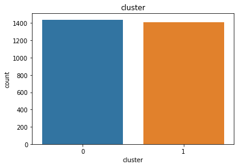

```python
sns.countplot(data=df_comp, x='cluster')
plt.title('cluster')
```

Pembagian label cukup seimbang

> Categoricals Bivariate Analysis

```python
categoricals_comp = df_comp.select_dtypes(include=object).columns
categoricals_comp
```

```
Index(['Attrition', 'BusinessTravel', 'Department', 'EducationField', 'Gender',
       'JobRole', 'MaritalStatus', 'OverTime'],
      dtype='object')
```

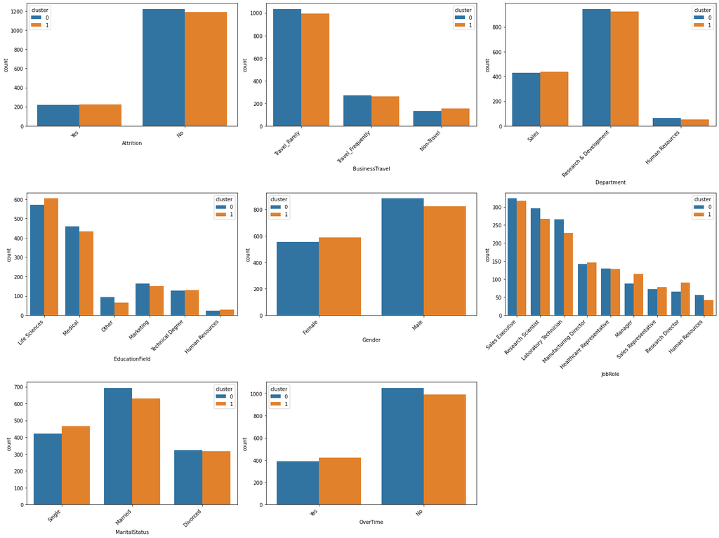

```python
cols = 3
rows = 3
fig = plt.figure(figsize= (20,15))
all_cat = df_comp[categoricals_comp]
cat_cols = df_comp[categoricals_comp].columns

for i, col in enumerate(cat_cols):
    ax=fig.add_subplot(rows, cols, i+1)
    sns.countplot(x=df_comp[col], hue=df_comp['cluster'], ax=ax)
    plt.xticks(rotation=45, ha='right')

fig.tight_layout()
plt.show()
```

> Insight:

Pembagian label tidak terlalu jelas terlihat dari sisi kategorikal, dimana setiap kategori memiliki label yang rata. Dengan kata lain, pembeda cluster tidak terletak pada fitur-fitur kategorikal di atas.

> Numericals Bivariate Analysis

```python
print(numericals_comp)
```

```
Index(['Age', 'DailyRate', 'DistanceFromHome', 'Education',
       'EnvironmentSatisfaction', 'HourlyRate', 'JobInvolvement', 'JobLevel',
       'JobSatisfaction', 'MonthlyIncome', 'MonthlyRate', 'NumCompaniesWorked',
       'PercentSalaryHike', 'PerformanceRating', 'RelationshipSatisfaction',
       'StockOptionLevel', 'TotalWorkingYears', 'TrainingTimesLastYear',
       'WorkLifeBalance', 'YearsAtCompany', 'YearsInCurrentRole',
       'YearsSinceLastPromotion', 'YearsWithCurrManager', 'cluster'],
      dtype='object')
```

```
Label Numerical Distributions
```

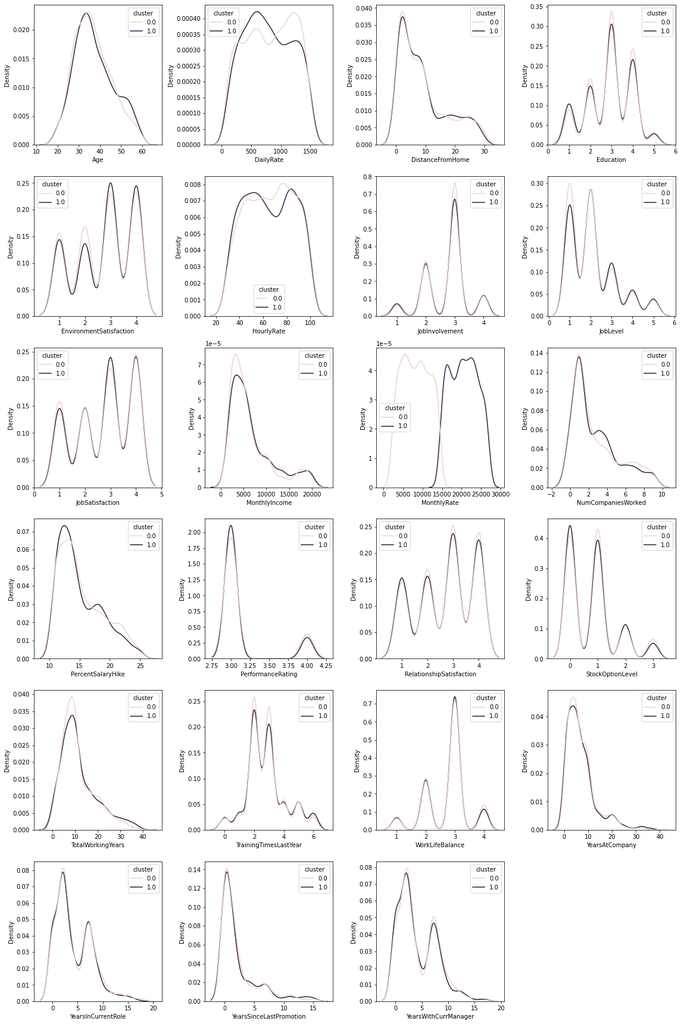

```python
cols = 4
rows = 6
num_cols = ['Age', 'DailyRate', 'DistanceFromHome', 'Education',
       'EnvironmentSatisfaction', 'HourlyRate', 'JobInvolvement', 'JobLevel',
       'JobSatisfaction', 'MonthlyIncome', 'MonthlyRate', 'NumCompaniesWorked',
       'PercentSalaryHike', 'PerformanceRating', 'RelationshipSatisfaction',
       'StockOptionLevel', 'TotalWorkingYears', 'TrainingTimesLastYear',
       'WorkLifeBalance', 'YearsAtCompany', 'YearsInCurrentRole',
       'YearsSinceLastPromotion', 'YearsWithCurrManager']
fig = plt.figure( figsize=(cols*4, rows*4))
print('Label Numerical Distributions')

for i, col in enumerate(num_cols):
    ax=fig.add_subplot(rows,cols,i+1)
    sns.kdeplot(x = df[col], hue=df_comp['cluster'], ax = ax)

fig.tight_layout()
plt.show()
```

> Insight:

Hal yang paling jelas membedakan antara cluster 1 dan 0 terletak pada monthly rate.

Dapat dikatakan, interpretasi cluster ini antara lain:

0 = low monthly rate employee  
1 = high monthly rate employee

# **Kesimpulan**

Hal yang dapat dilihat dari proyek ini adalah:

1. Perusahaan bergerak pada bidang kesehatan, research and development.
2. Perusahaan memiliki pemanfaatan SDM yang efektif dan efisien.
3. Model Klasifikasi memiliki performa yang sangat baik dan dapat segera dideploy.
4. Model Regresi masih perlu perbaikan secara mendalam.
5. Model Clustering membagi cluster karyawan kepada dua tipe: **Karyawan dengan monthly rate tinggi** dan **Karyawan dengan monthly rate rendah**